# 时空可解释分析工具BSTVC

### 4.6.6 目标变量的时空预测

```
# ---------------------------------------------------------------------
# 1. 加载所有必要的 R 包
# ---------------------------------------------------------------------
library(readxl) # 用于读取 Excel 预测数据
library(ggplot2) # 核心绘图包
library(dplyr) # 核心数据清洗与处理包
library(ggthemes) # 提供图表主题 (theme_few)
library(sf) # 核心空间数据处理包
library(viridis) # 提供学术级连续型色带
# ---------------------------------------------------------------------
# 2. 数据读取与预处理
# ---------------------------------------------------------------------
cat("\n👉 步骤 1/2: 请在弹出的窗口中选择HALE12_all_result_tables.xlsx\n")
excel_file <- file.choose()
predict_df <- read_excel(excel_file, sheet = "local.prediction")
# 查看输出字段结构，确保包含 'y' 和 'predict_y'
cat("\n--- Excel 数据结构预览 ---\n")

str(predict_df)

cat("\n👉 步骤 2/2: 请在弹出的窗口中选择TestMap_Continuous.shp\n")
shp_file <- file.choose()
world_map <- st_read(shp_file)
```

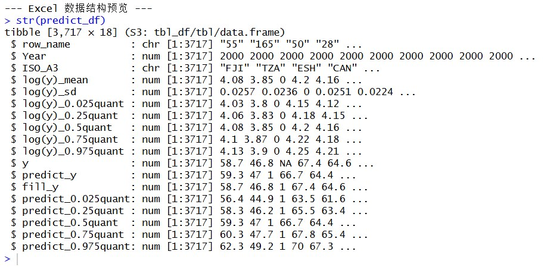

其中，对于变量Y所有类型（连续型、计数型与二值型）的局部预测结果，输出数据框中Year与ISO_A3为时间字段与空间字段，y字段代表目标变量Y的原始值，fill_y字段代表对目标变量Y中缺失值进行预测填补后的完整字段，predict_y代表为所有单元的模型预测值。

【备注】针对连续型的变量Y，由于模型设置的是log-Gaussian先验分布，目标变量Y会自动进行对数变换，故我们对输出结果进行了再变换，并设置“predict_”前缀。因此，(predict_0.025quant,predict_0.975quant)即为预测值的宽可信区间，(predict_0.25quant,predict_0.75quant)即为预测值的窄可信区间；

此外，基于局部预测的结果，可进行主流的预测精度（如散点图、R2、RMSE等）的评价。下面以连续型建模结果为例，我们给出绘制散点图、计算R2、RMSE以及绘制预测后的Y的时空分面可视化地图的代码：

```
# ---------------------------------------------------------------------
# 3. 预测精度评估：散点图与指标计算
# ---------------------------------------------------------------------
cat("\n--- 正在处理数据并绘制精度评估散点图 ---\n")
# 数据清洗：剔除带有缺失值 (NA) 的行
predict_normal_clean <- predict_df %>% filter(!is.na(y) & !is.na(predict_y))
# 计算评估指标：决定系数 (R²) 和 均方根误差 (RMSE)
R2_normal <- 1 - ((sum((predict_normal_clean$predict_y - predict_normal_clean$y)^2)) / (sum((mean(predict_normal_clean$y) - predict_normal_clean$y)^2)))
RMSE_normal <- sqrt(mean((predict_normal_clean$predict_y - predict_normal_clean$y)^2))
# 控制台打印结果
cat(paste("\n计算结果 -> R²:", round(R2_normal, 4), " | RMSE:", round(RMSE_normal, 4), "\n"))
# 构造要显示在图表右下角的文本内容
text_normal <- paste0("R² = ", round(R2_normal, 4), "\nRMSE = ", round(RMSE_normal, 4))
# 绘制高清晰度散点图
p_scatter <- ggplot(predict_normal_clean, aes(x = y, y = predict_y)) +
geom_abline(slope = 1, intercept = 0, color = "#e74c3c", linewidth = 1, linetype = "dashed") +
geom_smooth(method = "lm", se = FALSE, color = "#2980b9", linewidth = 1) +
geom_point(aes(fill = y), size = 3, shape = 21, color = "gray40", alpha = 0.8, stroke = 0.5) +
scale_fill_gradient(low = "#88d8db", high = "#b8aeeb") +
annotate("text", x = Inf, y = -Inf, label = text_normal,
hjust = 1.1, vjust = -0.5, family = "serif", fontface = "bold", size = 5) +
labs(x = "Measured Values", y = "Predicted Values", title = "Scatter Plot of Global Predictions") +
theme_few() +
theme(
text = element_text(family = "serif", face = "bold"),
axis.text = element_text(family = "serif", size = 12, face = "bold"),
plot.title = element_text(hjust = 0.5, size = 15, margin = margin(b = 15)),
legend.position = "none"
)
# 在 R 环境中先行展示散点图
cat("\n📊 正在 R 绘图窗口中展示散点图...\n")
print(p_scatter)
```

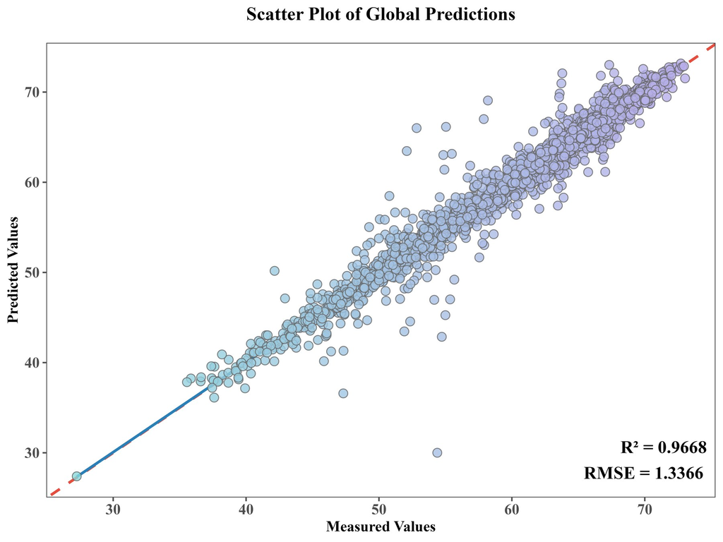

```
# ---------------------------------------------------------------------
# 4. 时空分面地图：关键时间节点可视化 (2000-2020)
# ---------------------------------------------------------------------
cat("\n--- 正在生成时空分面地图 ---\n")
# 数据拼接与年份筛选
map_data <- world_map %>%
left_join(predict_df, by = "ISO_A3") %>%
filter(!is.na(Year)) %>%
filter(Year %in% c(2000, 2005, 2010, 2015, 2020))
# 绘制时空分面地图
p_map <- ggplot(data = map_data) +
geom_sf(aes(fill = predict_y), color = "white", linewidth = 0.1) +
coord_sf(expand = FALSE) +
facet_wrap(~ Year, ncol = 2) +
scale_fill_gradientn(
colors = c("#313695", "#abd9e9", "#ffffbf", "#fdae61", "#a50026"),
na.value = "gray90"

) +

labs(
title = "Spatio-Temporal Distribution of Predicted Values",
fill = "Predicted Y\n"

) +

theme_void() +
theme(
text = element_text(family = "serif", face = "bold"),
plot.title = element_text(hjust = 0.5, size = 22, margin = margin(t = 10, b = 25)),
strip.text = element_text(size = 18, margin = margin(t = 10, b = 15)),
panel.spacing.x = unit(1.5, "lines"),
panel.spacing.y = unit(2.0, "lines"),
legend.position = "bottom",
legend.title = element_text(size = 14, vjust = 0.8),
legend.text = element_text(size = 12),
legend.key.width = unit(4, "cm"),
legend.key.height = unit(0.5, "cm"),
plot.background = element_rect(fill = "white", color = NA),
panel.background = element_rect(fill = "white", color = NA),
plot.margin = margin(t = 20, r = 20, b = 20, l = 20)
)
# 【关键步骤】在 R 环境中先行展示空间分面地图
cat("\n🗺️.r内展示空间有限，图片混乱是正常的，建议在保存目录中查看.\n")
print(p_map)
# ---------------------------------------------------------------------
# 5. 图表高清导出保存
# ---------------------------------------------------------------------
cat("\n--- 正在导出高分辨率图片至工作目录 ---\n")
# 导出散点图
ggsave("Scatter_Plot_HighRes.png", plot = p_scatter, width = 8, height = 6, dpi = 600)
# 导出时空分面地图
ggsave("Spatio_Temporal_Map_5Years.png", plot = p_map, width = 16, height = 18, dpi = 600, limitsize = FALSE)
cat("\n✅ 所有处理完毕！图片已保存到你的当前工作目录 (Working Directory) 下。\n")
```

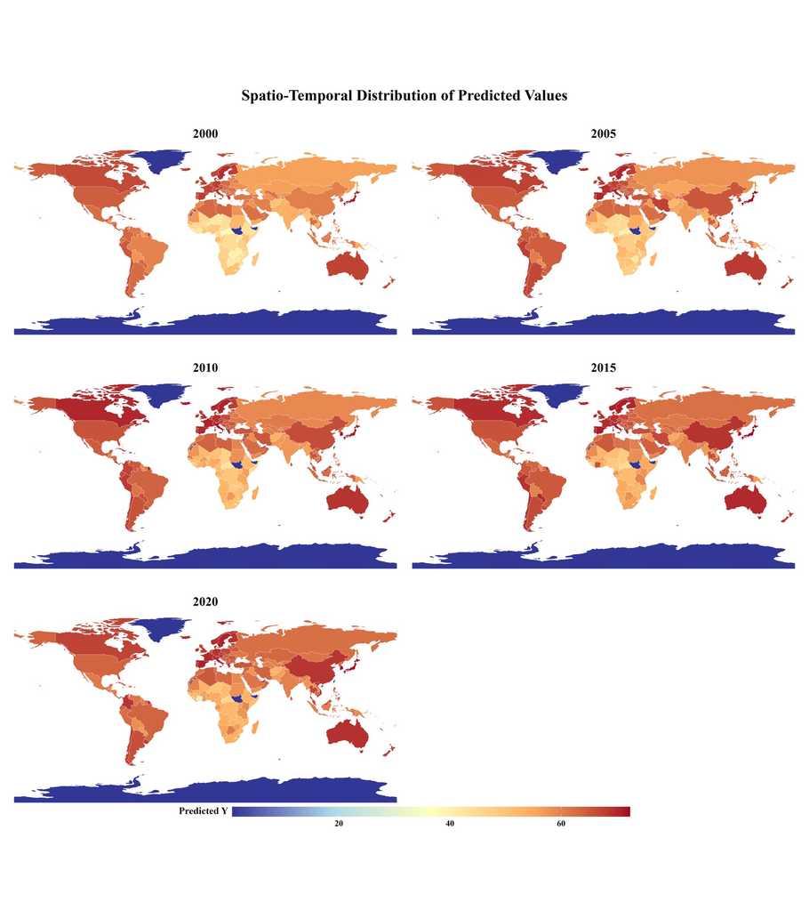

# 5. 实证案例II: 二分类目标变量

## 5.1 示例数据

本案例以中国省级层面的新冠肺炎疫情发生情况（二分类结局变量）时空面板数据为例进行演示，使用的数据整合自国家卫生健康委员会、多源遥感卫星监测以及百度人口迁徙大数据平台，收集了2020年全年中国大陆31个省份（自治区、直辖市）地区的人口流动、社会经济与自然环境等因素的真实数据变量，具体数据介绍如表5.1所示。

表5.1 案例Ⅱ示例数据

| 来源 | 变量 | 单位 | 编号 |
| --- | --- | --- | --- |
| 国家卫生健康委员会 | 新冠肺炎疫情发生情况 | 0=无, 1=有 | covid |
| 多源遥感卫星监测 | 归一化植被指数 | 无量纲 | NDVI |
| 多源遥感卫星监测 | 夜间灯光指数 | 无量纲 | NTL |
| 气象与环境监测平台 | PM2.5浓度 | μg/m³ | PM25 |
| 气象与环境监测平台 | 平均气温 | ℃ | Temp |
| 百度人口迁徙大数据平台 | 省际迁入规模指数 | 无量纲 | Total_In |
| 百度人口迁徙大数据平台 | 省际迁出规模指数 | 无量纲 | Total_Out |

## 5.2 数据输入与验证

本教程以案例Ⅱ示例数据为例进行数据导入，用户可以根据自己的数据进行相应操作。

步骤说明：

Step 1

双击打开桌面快捷方式图标BSTVC

**数据转换：**本案例原始数据为含多个时间信息的空间截面数据，故需先进行数据转换。而这里的“截面数据”和“时空面板数据”本质上包含相同的信息，区别主要在于数据的组织方式不同，如下图所示。截面数据格式是将每个地区作为一行，将不同时间点的变量值展开为不同列。例如，地区A一行中同时包含变量1在T1、T2的取值，也包含变量2、变量3、变量4在T1、T2的取值。这种格式更像是“宽表”，适合用户从原始统计表或多期截面数据中整理数据。时空面板数据格式则是将“时间ID”和“地区ID”共同作为行标识，每一行表示某一地区在某一时间点的观测值。例如，T1-地区A是一行，T2-地区A又是另一行，变量1至变量4分别作为列。这种格式更像是“长表”，也是软件进行BSTVC时空建模时使用的标准输入格式。需要注意的是，地区A、B、C、D的顺序原则上应与地图文件中的地区顺序保持一致；如果顺序不一致也没关系，本软件提供数据检查和自动转换模块，可帮助用户检查并调整数据顺序。

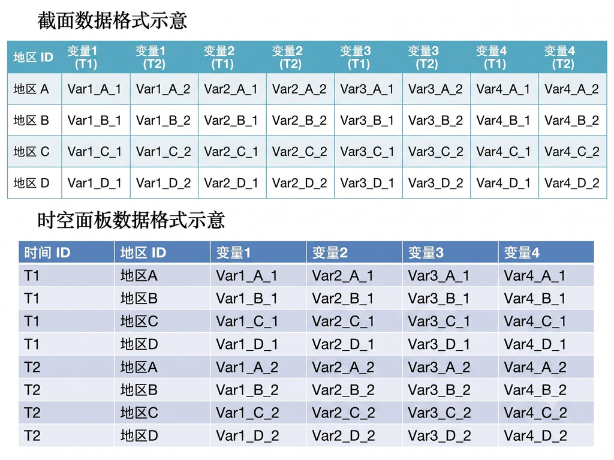

Step 2

在左侧导航栏选择“数据转换”模块，点击读取转换数据，导入原始数据。读取转换数据，下图显示即为读取成功

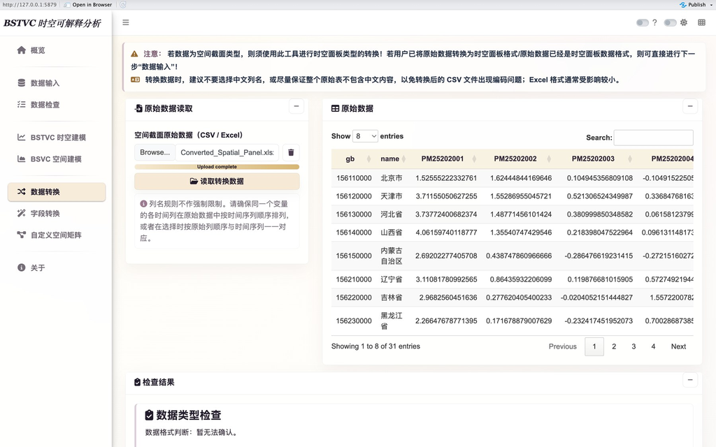

Step 3

下滑进行转换参数操作。首先选择id列（即在不同的时间点，该列的属性信息不会发生变化，如空间单元的编码列、名称列等等），本例中选择了空间截面数据的空间识别序号（gb）作为唯一识别id。在时间序列中输入数据时间范围（本例为1:12，代表1-12个月），新时间列名（Mouth），确定需转换的变量数量。本例为7个，输入后会自动生成需转换变量7个变量。

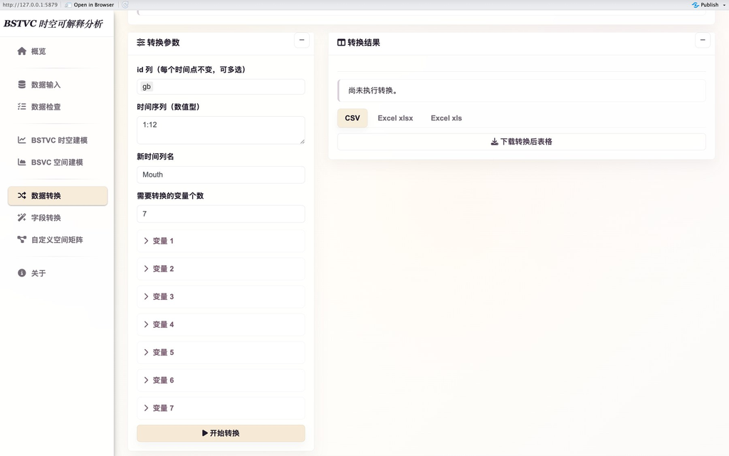

Step 4

在选取转换原始相关数据时，若该数据是连续的列变量，可直接从“起始列和终止列”进行自动连续列读入。若为间隔的列变量，则需在“该变量对应的时间序列”逐一选择输入。以PM25数据为例，原始数据名为PM25202001至PM25202012，设置转换后名统一为PM25。在起始列选择PM25202001，终止列选择PM25202012（可以通过选择列表输入，也支持检索输入），点击“按范围选择”即可选中12个月的数据。按照此操作，依次读取剩余变量，最后点击“开始转换”。

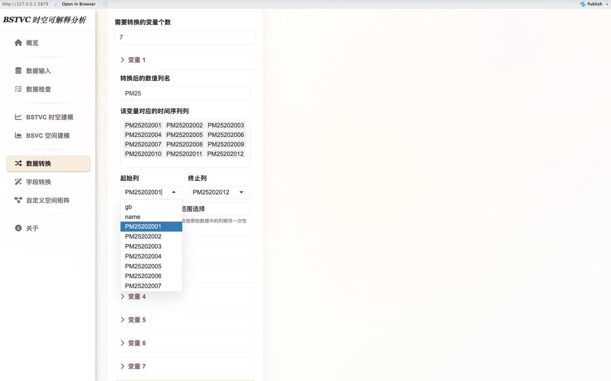

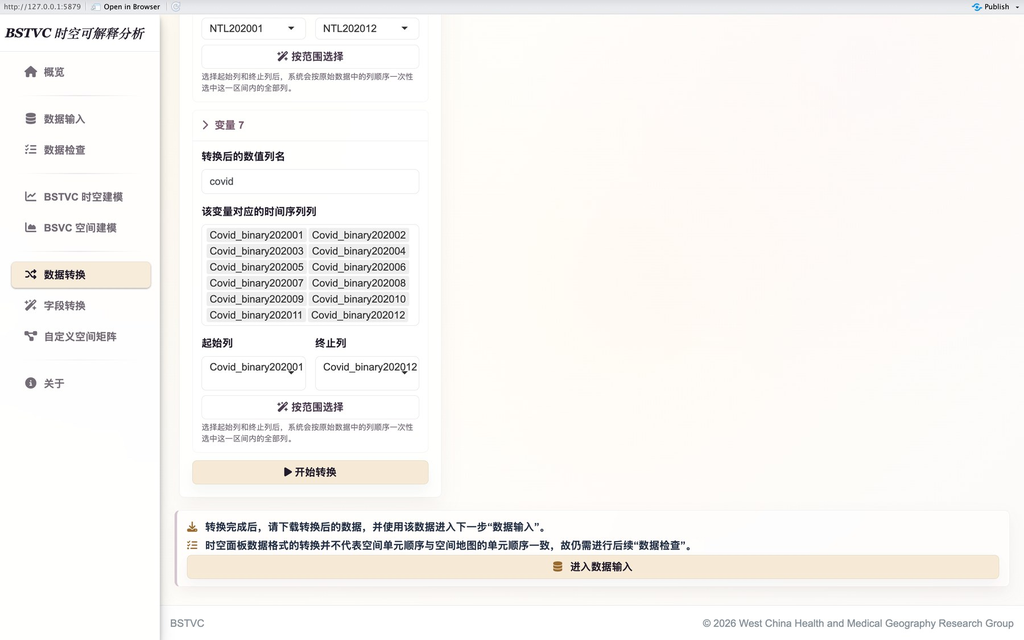

Step 5

转换完成后如下图所示。注意需下载转换后表格并存储在本地后，再进行下一步的数据输入。本程序支持.csv、.xlsx、.xls三种存储格式，本案例以存储为.xlsx格式为例进行展示

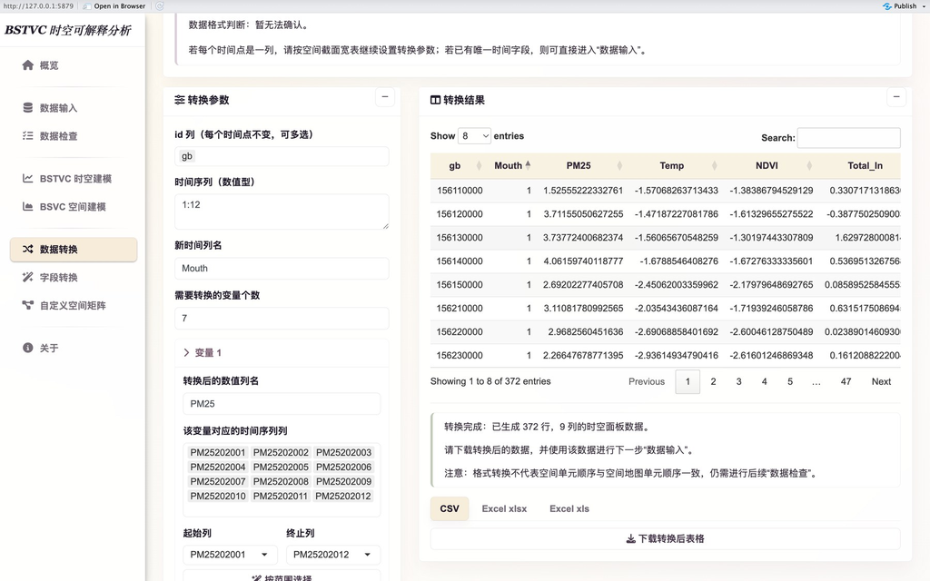

Step 6

**数据输入：**在左侧导航栏选择数据输入模块（或从上一步最底部点击进入数据输入），导入上一步存储的转换后数据，BSTVC_panel_converted.xlsx。

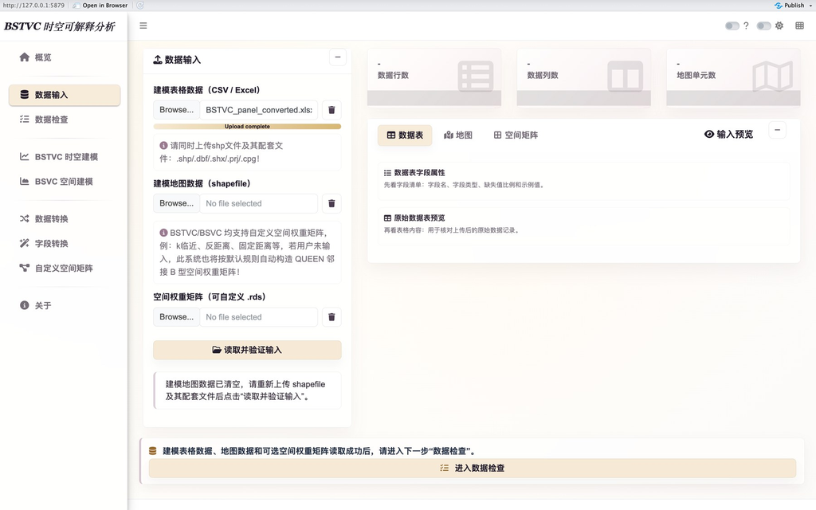

Step 7

导入建模地图数据完整文件，空间权重矩阵保持默认，不用输入设置，按默认规则自动构造QUEEN邻接型空间权重矩阵。关于自定义空间权重矩阵的说明，可见4.2小节。

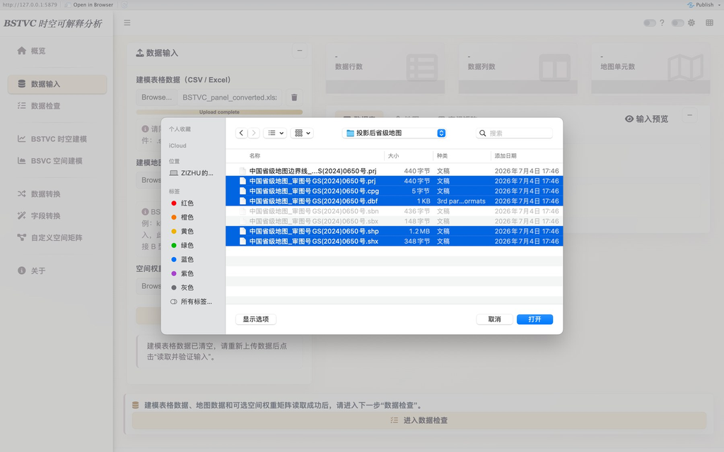

Step 8

点击读取并验证输入，导入成功后可见最左下框提示读取成功。读取成功后，右侧数据表模块上方可见数据表字段属性如字段名、字段类型、缺失值比例等；下方可见原始数据预览。

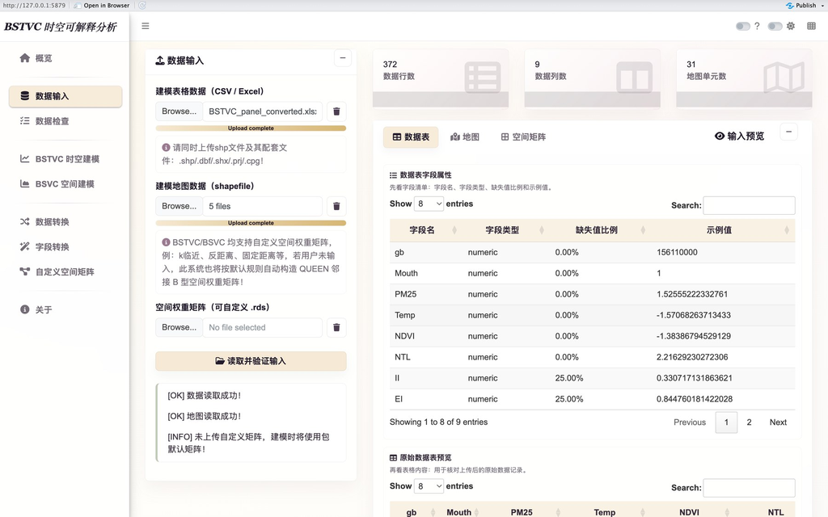

Step 9

读取成功后，右侧地图模块，上方可见地图属性模块，下方可见研究区域空间预览

[figure not shown]

【备注】在BSTVC支持的时空面板数据中，变量Y可以包含缺失值，变量X也可容忍少量缺失值。在用户导入自己的数据前，需注意：①缺失值请使用“NA”表示，便于识别；②检查表格数据与地图数据中的空间唯一标识码的字段类型，确保两个表中的该字段的名称和类型一致。

## 5.3 数据检查

### 5.3.1 空间单元顺序检查

建模表格数据中的每个时间节点下空间单元的顺序需要与建模地图数据中的shapefile文件中空间单元的顺序完全一致，不一致会造成最终结果不正确，但模型运行并不会报错的情况。BSTVC时空可解释平台提供一键式自动比对数据表与地图中的空间单元唯一值字段的功能，完成空间序列的自动化重排与对齐。

步骤说明：

Step 1

点击左侧导航栏的数据检查模块（或从上一步最底部点击进入数据检查），转入数据检查模块。

Step 2

检查模式选择BSTVC时空面板，时间字段Time选择唯一识别字段Mouth，空间字段Space选择唯一识别字段gb。

Step 3

点击运行检查，平台自动完成空间序列的重排与对齐。检查结果显示已完成后，即可选择进入BSTVC建模。

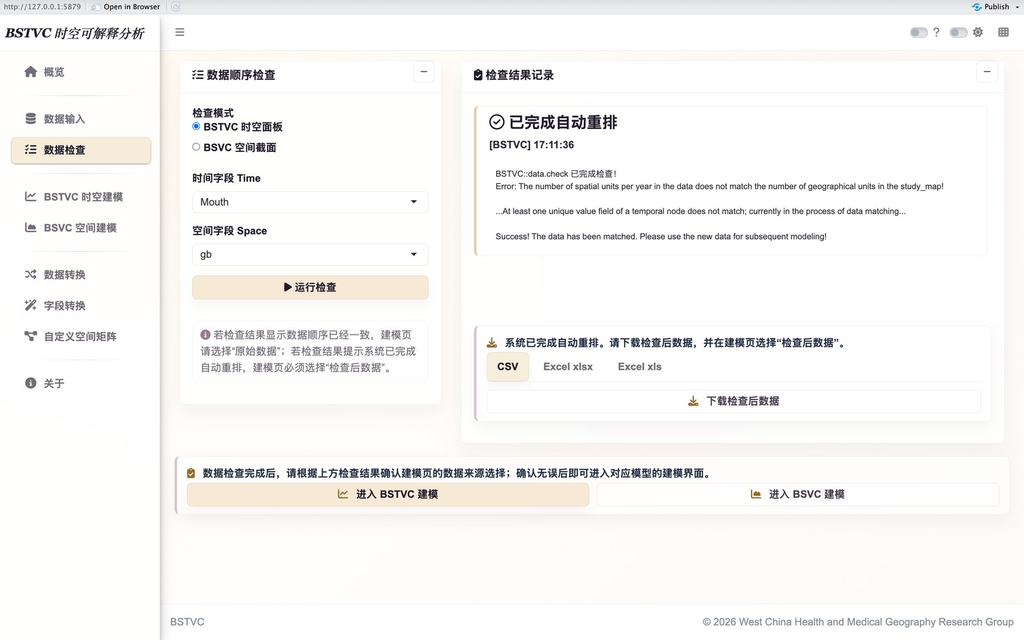

### 5.3.2 字段类型检查

在建模前，用户需要特别注意字段类型问题。具体原因、步骤及说明详见4.3.2小节。

## 5.4 BSTVC建模

构建BSTVC时空模型所需的参数主要有9个，具体参数描述详见4.4小节BSTVC时空建模。

操作步骤如下：

Step 1

点击左侧导航栏的BSTVC时空建模模块（或从上一步最底部点击进入BSTVC时空建模），转入BSTVC时空建模。

Step 2

因数据自动重排，故数据来源需选择检查后数据；优先选择解释变量标准化，空间权重矩阵默认选择QUEEN-B，线程数threads默认值为6。

Step 3

依次输入数据的响应变量Y（本例为covid），解释变量X（本例为PM25、Temp等），响应类型为二分类binary，时间字段为Mouth，空间字段为gb（务必和地图数据为同一字段名）。输入变量完成后应如下图所示

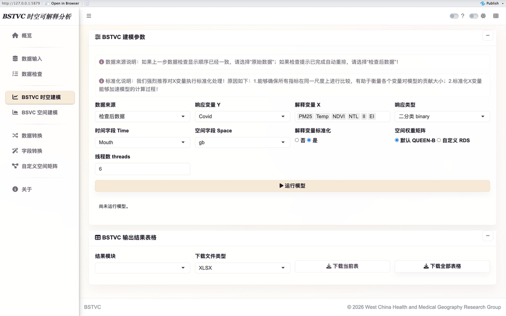

Step 4

完成上述参数准备后，点击运行模型，等待运行。

Step 5

下图是成功运行完成后的示例图。在BSTCV输出表格总计6个板块，可直接点击下载全部表格保存所有结果。

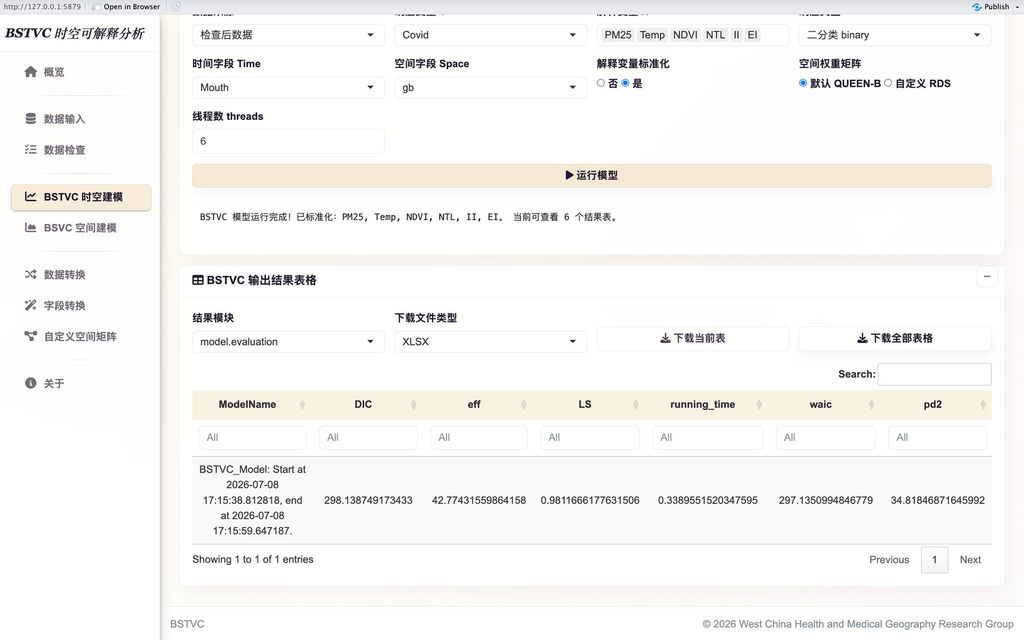

## 5.5 模型结果

BSTVC函数输出的结果共包括6个部分，具体输出部分描述同4.5小节。

## 5.6 BSTVC模型输出及其可视化

在本文档中，我们将详细提供一系列的绘制模型输出结果的步骤和代码示例，以便您能够轻松地在R环境中创建各种图表。我们的目标是让您不仅能够理解模型的输出，还能够通过图表的形式，将这些复杂的数据以更直观、更吸引人的方式呈现出来。

本文档在此部分展示的所有图表和可视化结果均基于示例数据构建的模型的输出。以下绘图代码及图件供参考。

### 5.6.1 模型的贝叶斯评价

模型的贝叶斯评价包括模型名称（包含建模起始时间）、DIC、LS、WAIC、pd2等指标。其中，DIC、WAIC表示模型拟合度，eff（DIC）和pd2（WAIC）表示模型复杂度，LS表示预测精度。具体而言，DIC和WAIC值越小表示模型拟合度越好，eff和pd2值越小表示模型复杂度越低，LS值越接近0表示预测精度越高。

```
# 2 模型的贝叶斯评价 ---------------------------------------------------------------
# 1. 安装并加载必要的R包（如果还没有安装，请先取消下一行的注释进行安装）
# install.packages("readxl")
library(readxl)
# 2. 设置你的文件路径
file_path <- "/Users/xxx/Binary/BSTVC_all_result_tables.xlsx"
# 3. 读取 Excel 文件中的 Sheet1 (即 model.evaluation)
# 假设数据在第一个Sheet中，也可以用 sheet = "Sheet1" 指定
model.eval <- read_excel(file_path, sheet = 1)
# 4. 指标水平展示（原始格式）
cat("\n## 指标水平展示\n")
print(model.eval)
# 5. 指标垂直展示
cat("\n## 指标垂直展示）\n")
# 因首列含中文故使用t()转置，此时所有数据会变成字符矩阵
model.eval_t <- t(model.eval)
print(model.eval_t)
```

- 结果如下：

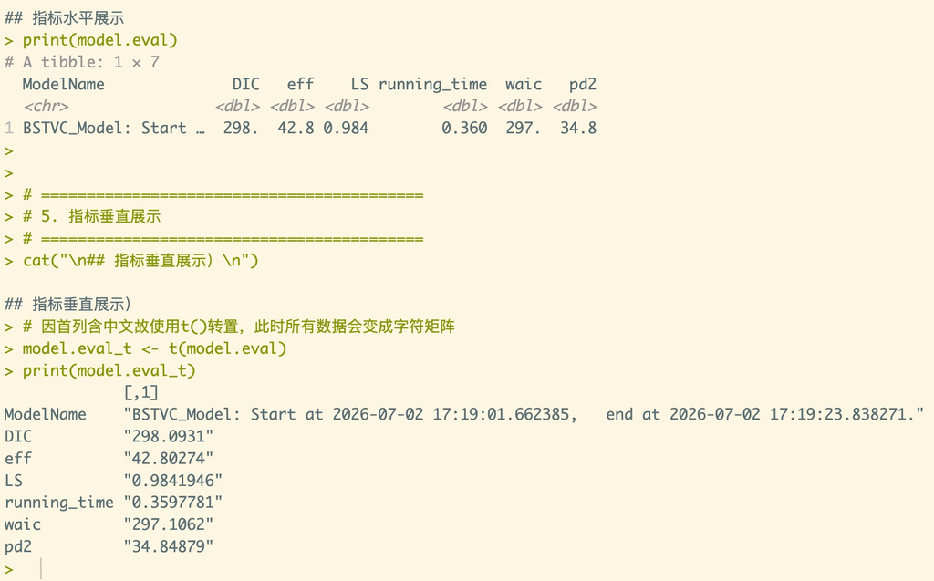

### 5.6.2 时间回归系数（时间非平稳）

BSTVC模型不仅可以计算时间回归系数来刻画变量关系的时间异质性，还可以估算出每个回归系数值的贝叶斯宽（95%）、窄（50%）可信区间，用于直接评价结果的不确定性。

```
# 时间非平稳----时间回归系数的时间序列展示形式

rm(list=ls())
gc()

library(ggplot2)
library(dplyr)
library(readxl)
library(showtext)

showtext_auto()

# --- 1. 读取数据---
excel_file <- "/Users/xxx/BSTVC-covid/Binary/BSTVC_all_result_tables.xlsx"
Time.Coef_raw <- as.data.frame(read_excel(excel_file, sheet = "time.coefficients"))
# --- 2. 数据清洗与格式转换 ---
Time.Coef <- Time.Coef_raw %>%
mutate(Coefficients = round(mean, 2), Month = time_index)
names(Time.Coef)[names(Time.Coef) == "0.025quant"] <- "q025"
names(Time.Coef)[names(Time.Coef) == "0.975quant"] <- "q975"
names(Time.Coef)[names(Time.Coef) == "0.25quant"] <- "q25"
names(Time.Coef)[names(Time.Coef) == "0.75quant"] <- "q75"
Time.Coef$q025 <- as.numeric(Time.Coef$q025)
Time.Coef$q975 <- as.numeric(Time.Coef$q975)
Time.Coef$q25 <- as.numeric(Time.Coef$q25)
Time.Coef$q75 <- as.numeric(Time.Coef$q75)
Time.Coef$explain_variable <- gsub("time\\.", "", Time.Coef$explain_variable)
# --- 3. 绘制时间系数图 ---
p_time <- ggplot(data = Time.Coef, aes(x = Month, y = Coefficients, fill = explain_variable)) +
geom_ribbon(aes(ymin = q025, ymax = q975, fill = explain_variable), alpha = 0.2) +
geom_ribbon(aes(ymin = q25, ymax = q75, fill = explain_variable), alpha = 0.5) +
geom_line(aes(x = Month, y = Coefficients, colour = explain_variable), linewidth = 1) +
facet_wrap(~explain_variable, scales = "free_y", ncol = 3) +
theme_bw() +
scale_x_continuous(breaks = 1:12) +
labs(title = "各因素影响的时间演变趋势 (2020年月度)", x = "月份", y = "时间系数 (Log-Odds)") +
theme(
legend.position = "none",
# 图表四周的字体配置
plot.title = element_text(hjust = 0.5, face = "bold", size = 26, margin = ggplot2::margin(b = 15)),
# 1. 分面标题（变量名）
strip.background = element_rect(fill = "grey90", color = "black", linewidth = 0.8),
strip.text = element_text(size = 24, face = "bold", color = "black"),
# 2. 坐标轴刻度数字
axis.text = element_text(size = 24, color = "black"),
# 3. 坐标轴标题
axis.title = element_text(size = 24, face = "bold", margin = ggplot2::margin(t = 10, r = 10)),
panel.border = element_rect(color = "black", fill = NA, linewidth = 1),
panel.grid = element_blank(),
text = element_text(family = "wqy-microhei")
)
# =========================================================
# --- 4. 导出 ---
# =========================================================
ggsave(filename = "~/Desktop/Time_Coefficients_6Vars_.png", plot = p_time, width = 14, height = 8, dpi = 300)
```

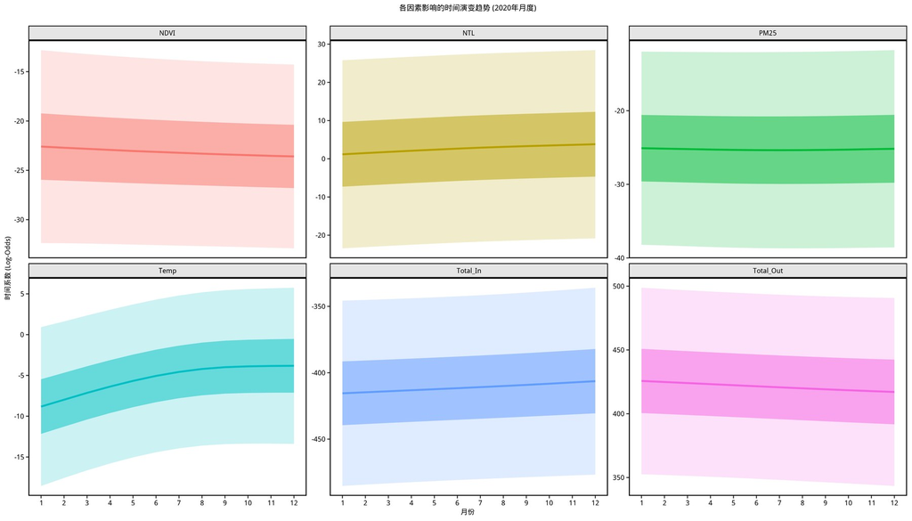

### 5.6.3 空间回归系数（空间非平稳）

与时间回归系数类似，BSTVC模型不仅可以计算空间回归系数表示空间异质的变量关系，还可以 估算其不确定性，即贝叶斯宽（95%）、窄（50%）可信区间。

提取出模型输出中的空间回归系数数据框后，建议在ArcGIS或ArcGIS Pro等专业地图制图软件中进行绘制。此处基于R语言，简单绘制出基础的空间回归系数 地图展示结果，仅供样本制图参考。

```
# 4 空间非平稳 -----------------------------------------------------------------
# 如果未安装 patchwork，请先取消下方注释进行安装
# install.packages("patchwork")
library(patchwork)
# =========================================================
# 提取所有需要画图的变量名
variables_to_plot <- unique(Space.coef.panel$variable)
# 使用 lapply 循环为每个变量单独画图
plot_list <- lapply(variables_to_plot, function(var_name) {
# 提取当前变量的数据
current_data <- Space.coef.panel %>% filter(variable == var_name)
# 单独绘图
p <- ggplot(current_data) +
geom_sf(aes(fill = SCs), color = "gray60", linewidth = 0.2) +
scale_fill_gradient2(
low = "#4575b4", mid = "white", high = "#d73027", midpoint = 0,
name = "SCs"

) +

theme_bw() +
# 将变量名作为每个小图的标题
labs(title = var_name) +
# 统一美化设置
theme(
legend.position = "bottom",
legend.key.width = unit(1.2, "cm"),
legend.title = element_text(face = "bold", size = 32),
legend.text = element_text(size = 30),
plot.title = element_text(hjust = 0.5, face = "bold", size = 38, margin = ggplot2::margin(b = 10)),
axis.text = element_blank(),
axis.ticks = element_blank(),
panel.grid = element_blank(),
panel.border = element_rect(color = "black", fill = NA, linewidth = 1),
text = element_text(family = "wqy-microhei")
)

return(p)
})

# 将 6 张图按 2行3列 拼接，并添加总标题
p_final <- wrap_plots(plot_list, ncol = 3) +
plot_annotation(
title = "各影响因子空间效应的非平稳性分布",
theme = theme(
plot.title = element_text(hjust = 0.5, face = "bold", size = 34, family = "wqy-microhei", margin = ggplot2::margin(b = 20))
)
)
# 导出图片
ggsave(
filename = "~/Desktop/Space_Coefficients_Map_Patchwork.png",
plot = p_final,
width = 16, # 稍微加宽一点画板以容纳 6 个独立图例
height = 10,
dpi = 300
)
```

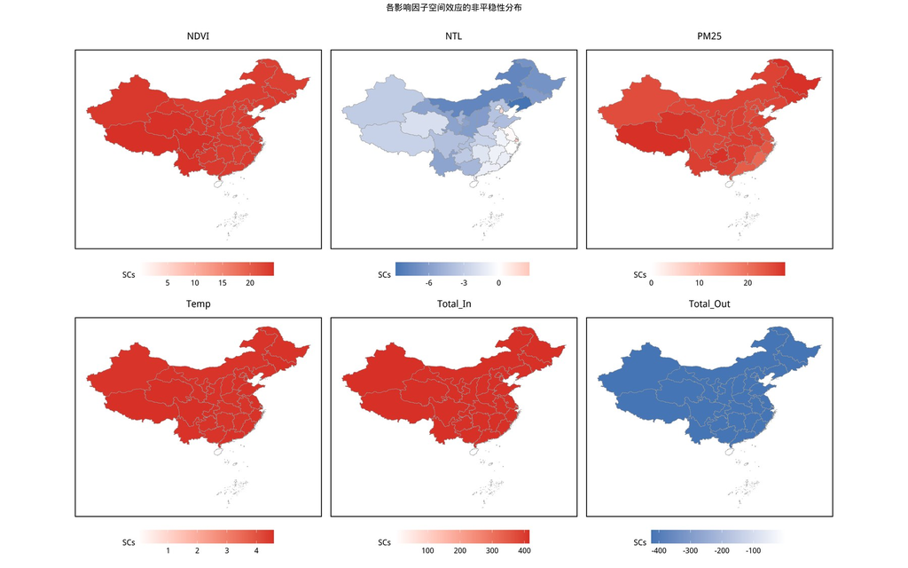

### 5.6.4 时空贡献度评价

**时空方差分割指标（Spatiotemporal Variance Partitioning Index，STVPI）**旨在量化并比较不同时空异质影响因素的可解释百分比，通过计算时空贡献度来明确关键驱动因素。基于BSTVC建模结果，STVPI进一步将每个解释变量的总方差分解为时间和空间两个独立的组分，即时间非平稳随机效应和空间非平稳随机效应，进而揭示数据的时空变异来源。

**此工具的优点有：**①不仅能识别解释因子的时空总体贡献，还能分别识别时间和空间维度的贡献；②相比只能识别绝对贡献排序的主流方法（如随机森林、SHAP等），STVPI识别的是相对贡献 （可解释百分比），为地理时空归为提供重要证据基础；③直接评价其不确定性（贝叶斯宽窄可信区间）

```
# 5 STVPI时空方差分割指标 -------------------------------------------------------------

rm(list=ls())
gc()

library(ggplot2)
library(dplyr)
library(readxl)
library(showtext)

showtext_auto()

# 1. 设置结果表格路径
my_path <- "/Users/xxx/BSTVC_all_result_tables(1).xlsx"
STVPI.data <- as.data.frame(read_excel(my_path, sheet = "STVPI"))
STVPI.data[,2:6] <- lapply(STVPI.data[,2:6], as.numeric)
colnames(STVPI.data) <- c("id", "STVPI_2.5", "STVPI_25", "STVPI_mean", "STVPI_75", "STVPI_97.5", "effect_name")
STVPI.data$effect_name <- trimws(STVPI.data$effect_name)
# 提取变量名
time_raw <- unique(STVPI.data$effect_name[grepl("^time\\.", STVPI.data$effect_name) & STVPI.data$effect_name != "time.all"])
my_factors <- unique(gsub("^time\\.", "", time_raw))
my_factors <- my_factors[!is.na(my_factors) & my_factors != ""]
# 划分四个组别
st_all_vars <- c("space.all", "time.all")
space_vars <- paste0("space.", my_factors)
time_vars <- paste0("time.", my_factors)
st_vars <- paste0("space.time.", my_factors)
# 2. 过滤并构建 4 个学术组别的数据
plot.data <- STVPI.data %>%
filter(effect_name %in% c(st_all_vars, space_vars, time_vars, st_vars)) %>%
distinct(effect_name, .keep_all = TRUE) %>%
mutate(Group = case_when(
effect_name %in% st_all_vars ~ "1. 时空总贡献度 (Space & Time Totals)",
effect_name %in% space_vars ~ "2. 空间贡献 (Space)",
effect_name %in% time_vars ~ "3. 时间贡献 (Time)",
effect_name %in% st_vars ~ "4. 时空贡献 (Space-Time)"
))
# 控制 Y 轴因子的上下排列顺序
plot.data$effect_name <- factor(plot.data$effect_name, levels = rev(c(st_all_vars, space_vars, time_vars, st_vars)))
# 3. 绘制STVPI图
p_combined <- ggplot(plot.data, aes(x = STVPI_mean, y = effect_name)) +
# 95% 置信区间
geom_errorbar(aes(xmin = STVPI_2.5, xmax = STVPI_97.5, colour = Group), width = 0, linewidth = 1.2, alpha = 0.5) +
# 50% 置信区间
geom_errorbar(aes(xmin = STVPI_25, xmax = STVPI_75, colour = Group), width = 0, linewidth = 2.5, alpha = 0.8) +
# 样式设置
geom_point(aes(colour = Group), shape = 124, size = 21, stroke = 0.9) +
geom_text(aes(label = sprintf("%.2f%%", STVPI_mean * 100)),
vjust = -1.6, hjust = 0.5, size = 10.6, fontface = "bold", family = "wqy-microhei") +
# 统一布局
facet_wrap(~Group, scales = "free_y", ncol = 2) +
theme_bw() +
scale_x_continuous(labels = scales::percent_format()) +
labs(title = "模型时空方差贡献度(STVPI)", x = "STVPI 贡献率百分比", y = "") +
theme(
legend.position = "none",
# 顶部小标题
strip.background = element_rect(fill = "grey90", color = "black", linewidth = 1),
strip.text = element_text(family = "wqy-microhei", size = 41, face = "bold", color = "black"),
# 设置字号样式
plot.title = element_text(hjust = 0.5, face = "bold", size = 41, family = "wqy-microhei", margin = ggplot2::margin(b = 20)),
axis.text.x = element_text(size = 41, color = "black"),
axis.text.y = element_text(size = 41, color = "black"),
axis.title.x = element_text(size = 41, face = "bold", margin = ggplot2::margin(t = 15)),
panel.border = element_rect(color = "black", fill = NA, linewidth = 1),
panel.grid.major = element_line(color = "grey95"),
panel.grid.minor = element_blank(),
# 增加画板四周的内边距
plot.margin = ggplot2::margin(t = 20, r = 20, b = 20, l = 20),
text = element_text(family = "wqy-microhei")
)
# 4. 导出图片
ggsave(filename = "~/Desktop/STVPI_Combined_4Facets_LongLine.png", plot = p_combined, width = 16, height = 13, dpi = 300)
```

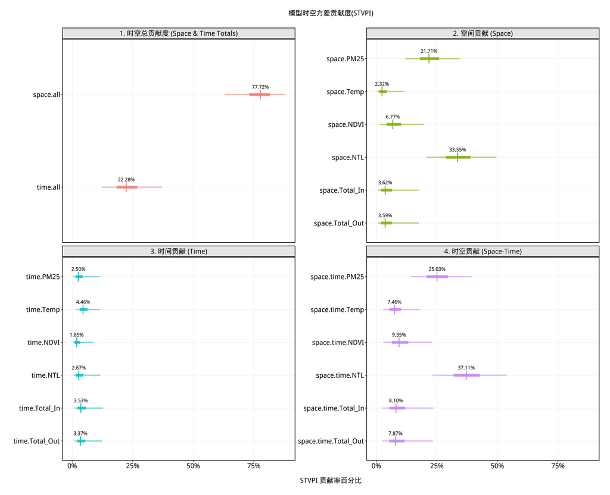

### 5.6.5 目标变量的时空预测

对于数据中目标变量Y的所有缺失值或非缺失值，局部预测结果中都会输出预测值，以及预测值的贝叶斯宽窄可信区间，用于直接评价不确定性。

其中，对于变量Y所有类型（连续型、计数型与二值型）的局部预测结果，y字段代表目标变量Y的原始值，fill_y字段代表对目标变量Y中缺失值进行预测填补后的完整字段，predict_y代表为所有单元的模型预测值。

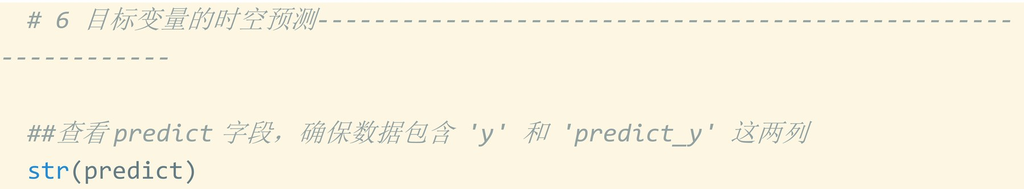

2）时空预测可视化

本案例选择绘制ROC曲线来动态展示灵敏度与误报率的权衡，并提供全局量化指标（AUC值），AUC值越大，说明预测效果越好。

```
## 绘制 Logistic-BSTVC: ROC 曲线 ---

rm(list=ls())
gc()

library(ggplot2)
library(dplyr)
library(readxl)
library(showtext)
library(pROC)

showtext_auto()

# 1. 文件路径
my_path <- "/Users/xx/BSTVC_all_result_tables(1).xlsx"
predict_data <- as.data.frame(read_excel(my_path, sheet = "local.prediction"))
# 提取没有缺失值的真实验证集部分
predict_clean <- predict_data %>% filter(!is.na(y))
# 2. 生成 ROC 对象并获取 AUC 值
roc_obj <- roc(predict_clean$y, predict_clean$predict_y, quiet = TRUE)
auc_value <- as.numeric(auc(roc_obj))
cat("\n==========================================\n")
cat(sprintf("模型预测精度 (AUC值): %.4f\n", auc_value))
cat("评价标准: 0.7~0.8(良好), 0.8~0.9(优秀), >0.9(极佳)\n")
cat("==========================================\n")
# 3. 提取用于 ggplot2 绘图的坐标点
roc_df <- data.frame(
FPR = 1 - roc_obj$specificities, # 假阳性率 (1 - 特异度)
TPR = roc_obj$sensitivities # 真阳性率 (灵敏度)
) %>%
arrange(FPR, TPR) # 确保 (0,0) 始终是连线的第一个点
# 4. 绘制ROC 图
p_roc <- ggplot(roc_df, aes(x = FPR, y = TPR)) +
# 绘制对角线和ROC曲线
geom_abline(slope = 1, intercept = 0, color = "grey50", linewidth = 1.5, linetype = "dashed") +
geom_path(color = "#b2182b", linewidth = 1) +
# 标注 AUC 值
annotate("text", x = 0.70, y = 0.25,
label = sprintf("AUC = %.3f", auc_value),
size = 24, fontface = "bold", color = "black", family = "wqy-microhei") +
theme_bw() +
# 为四周留出 2% 的物理边距
scale_x_continuous(limits = c(0, 1), expand = expansion(add = 0.02)) +
scale_y_continuous(limits = c(0, 1), expand = expansion(add = 0.02)) +
# 设置X 和 Y 轴比例
coord_fixed() +
labs(
title = "Logistic-BSTVC 模型预测精度评估 (ROC 曲线)",
x = "假阳性率 (1 - 特异度, FPR)",
y = "真阳性率 (灵敏度, TPR)"

) +

theme(
plot.title = element_text(hjust = 0.5, face = "bold", size = 46, margin = ggplot2::margin(b = 25)),
axis.text = element_text(size = 42, color = "black"),
axis.title.x = element_text(size = 44, face = "bold", margin = ggplot2::margin(t = 20)),
axis.title.y = element_text(size = 44, face = "bold", margin = ggplot2::margin(r = 20)),
# 外部边框
panel.border = element_rect(color = "black", fill = NA, linewidth = 2),
panel.grid.major = element_line(color = "grey90"),
panel.grid.minor = element_blank(),
plot.margin = ggplot2::margin(t = 20, r = 20, b = 20, l = 20),
text = element_text(family = "wqy-microhei")
)
# 5. 导出图片
ggsave(filename = "~/Desktop/Model_Evaluation_ROC_NoShade_Final.png", plot = p_roc, width = 10, height = 10, dpi = 300)
```

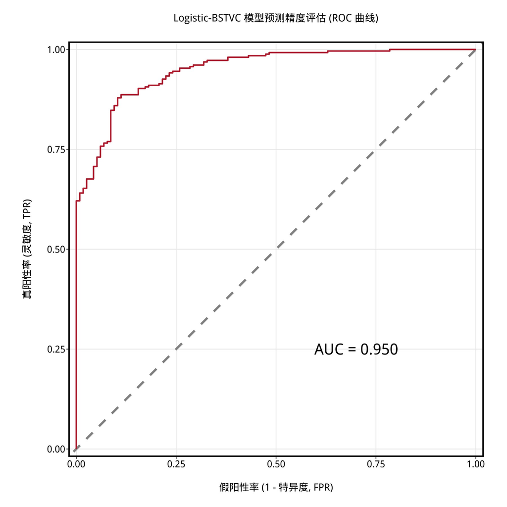

3）预测后的Y的时空分面可视化地图

```
## 预测后的 Y 的时空分面可视化地图

)# --- 清理环境与加载包 ---
rm(list=ls())
gc()

library(sf)
library(ggplot2)
library(dplyr)
library(readxl)
library(showtext)
library(ggthemes)

showtext_auto()

# 1. 设置文件路径
excel_file <- "/Users/xxx/BSTVC_all_result_tables(1).xlsx"
shp_file <- "/Users/xxx/中国省级地图_审图号GS(2024)0650号.shp"
# 2. 读取地图数据与预测结果
china_map <- st_read(shp_file)
predict_data <- as.data.frame(read_excel(excel_file, sheet = "local.prediction"))
# 3. 数据合并
predict_map <- china_map %>%
mutate(gb = as.character(gb)) %>%
left_join(
predict_data %>%
mutate(gb = as.character(gb)),
by = "gb"
) %>%
mutate(Month_CN = factor(Month,
levels = 1:12,
labels = c("一月", "二月", "三月", "四月", "五月", "六月",

"七月", "八月", "九月", "十月", "十一月", "十二月")))

# 4. 绘制时空分面可视化地图
p7 <- ggplot(predict_map) +
geom_sf(aes(fill = predict_y), color = "white", linewidth = 0.25) +
facet_wrap(~ Month_CN, ncol = 4) +
scale_fill_gradient(
low = "#e0f3db",
high = "#e34a33",
na.value = "grey90",
name = "预测概率"

) +

labs(
title = "各省份疫情发生概率的时空演变预测 (2020年)",
x = "",
y = ""

) +

theme_few() +
theme(
text = element_text(family = "wqy-microhei"),
plot.title = element_text(hjust = 0.5, face = "bold", size = 110, margin = ggplot2::margin(b = 50)),
axis.text = element_blank(),
axis.title = element_blank(),
axis.ticks = element_blank(),
panel.grid.major = element_blank(),
panel.border = element_rect(color = "grey35", fill = NA, linewidth = 0.6),
strip.background = element_rect(fill = "grey90", color = "grey35", linewidth = 0.6),
strip.text = element_text(size = 70, face = "bold"),
legend.title = element_text(size = 70, face = "bold", margin = ggplot2::margin(b = 20)),
legend.text = element_text(size = 60),
legend.position = "right",
legend.key.height = unit(5, "cm"),
legend.key.width = unit(2, "cm")
)
# 5. 导出高分辨率图片
ggsave(
filename = "~/Desktop/p7_predict_time_map_CN_NoLatLon_5xFont.png",
plot = p7,
width = 40,
height = 25,
dpi = 300,
limitsize = FALSE
)
```

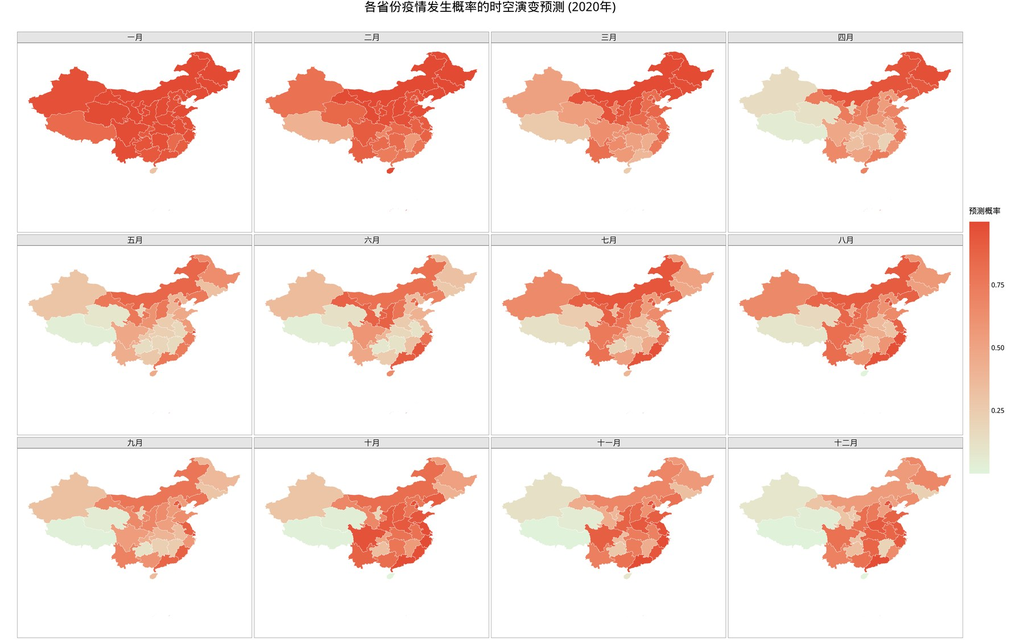

# 6. 实证案例III: 计数型目标变量

## 6.1 示例数据

本案例以美国洲级层面的急性乙肝监测病例（泊松型结局变量）时空面板数据为例进行演示，使用的数据美国CDC、美国社区调查（ACS）及美国国家环境信息中心（NOAA），收集了2012到2023年间美国阿巴拉契亚地区5个州（肯塔基州KY，北卡罗来纳州NC，田纳西州TN，弗吉尼亚州VA，西弗吉尼亚州WV）地区的社会经济与自然环境等因素的真实数据变量，具体数据介绍如表6.1所示，本示例数据无缺失。

表6.1 案例Ⅲ示例数据

| 来源 | 变量 | 单位 | 编号 |
| --- | --- | --- | --- |
| 美国疾控中心（CDC） | 急性乙肝监测病例 | 人 | COUNT |
| 美国国家环境信息中心 （NOAA） | 年降水量 | 英寸/年 | PRECIP |
| 美国社区调查 （ACS） | 人口密度 | 人/km² | PD |
| 美国社区调查 （ACS） | 贫困率 | 比例 | POV |
| 美国社区调查 （ACS） | 未参保率 | 比例 | UNINS |

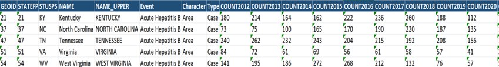

## 6.2 数据输入与验证

本教程以案例Ⅲ示例数据为例进行数据导入，用户可以根据自己的数据进行相应操作。

步骤说明：

Step 1

双击打开桌面快捷方式图标BSTVC

**数据转换：**本案例原始数据为含多个时间信息的空间截面数据，故需先进行数据转换。关于截面数据与时空面板数据的示例、示意图与解释说明，可见5.2小节。在左侧导航栏选择数据转换模块，点击读取转换数据，导入原始数据

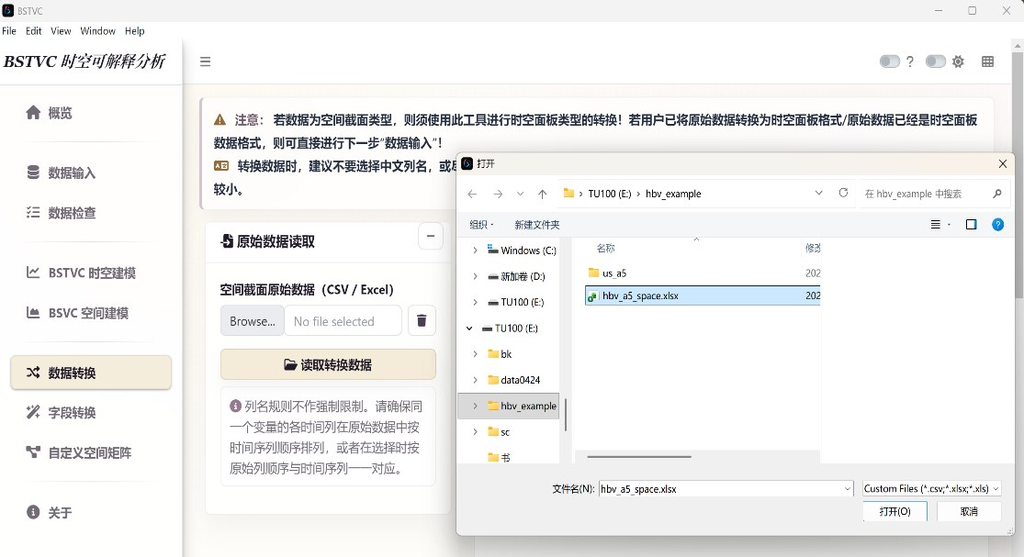

Step 2

读取转换数据，下图显示即为读取成功

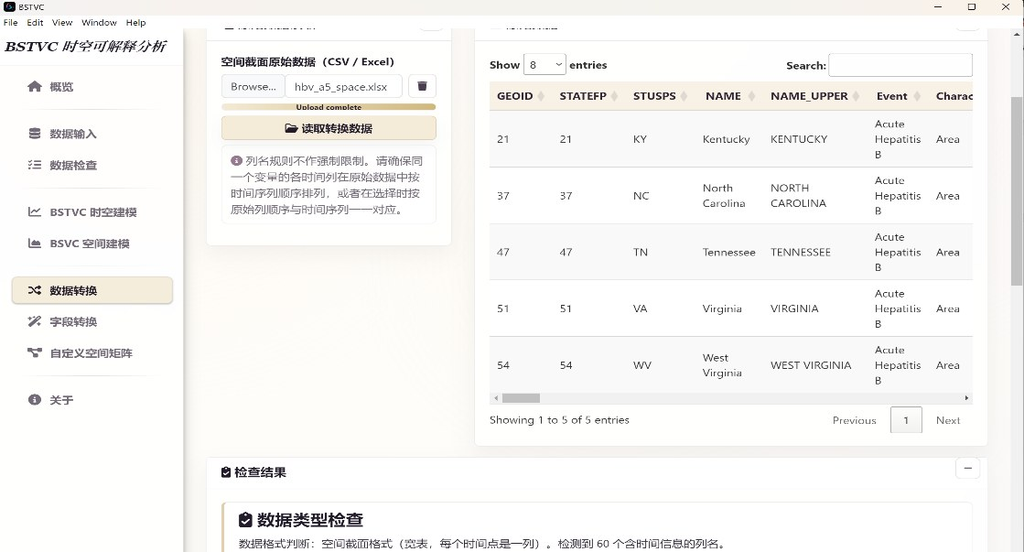

Step 3

下滑进行转换参数操作。首先选择id列，本例中选择了空间截面数据的空间识别序号作为唯一识别id（本例为geoid变量）。在时间序列中输入数据时间范围（本例为2012：2023），新时间列名（本例为Year）

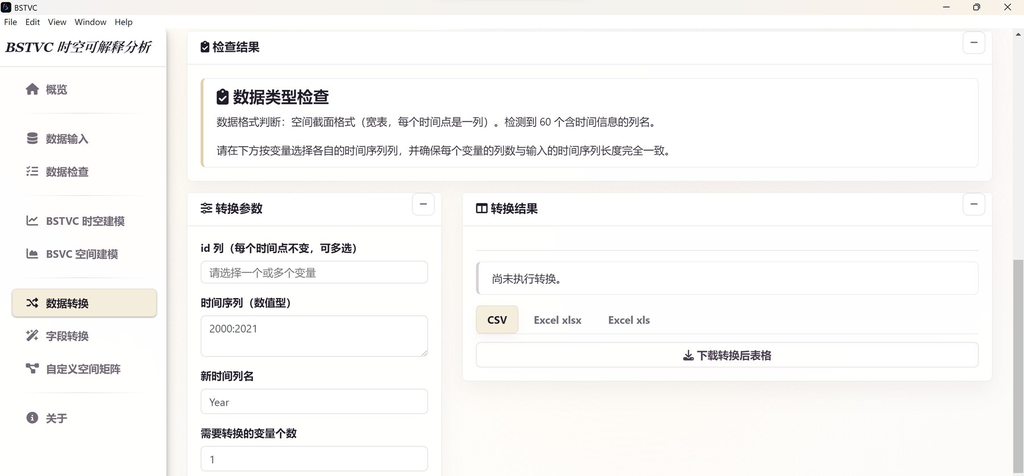

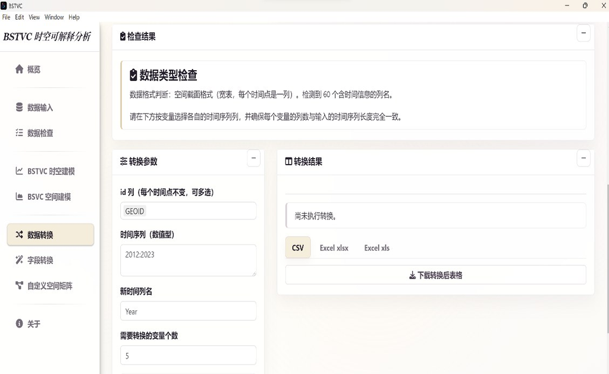

Step 4

确定需转换的变量数量。本例为5个，输入后会自动生成需转换变量5个变量。在选取转换原始相关数据时，若该数据是连续的列变量，可直接从“起始列和终止列”进行自动连续列读入。若为间隔的列变量，则需在“该变量对应的时间序列”逐一选择输入。

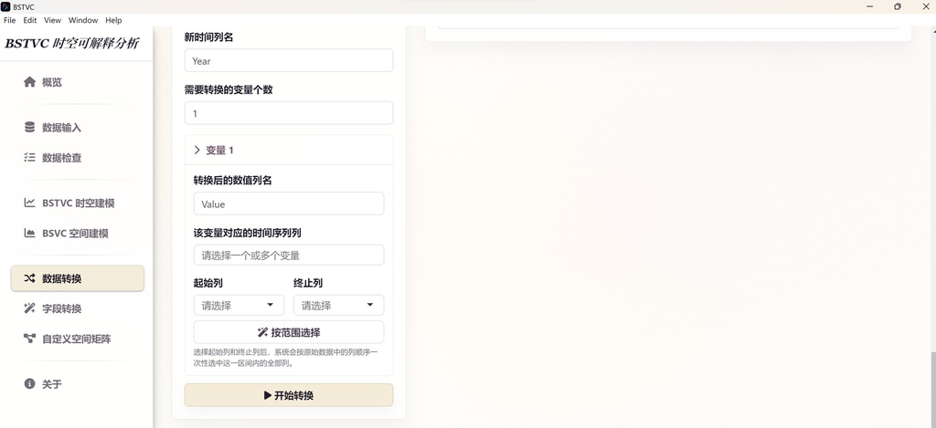

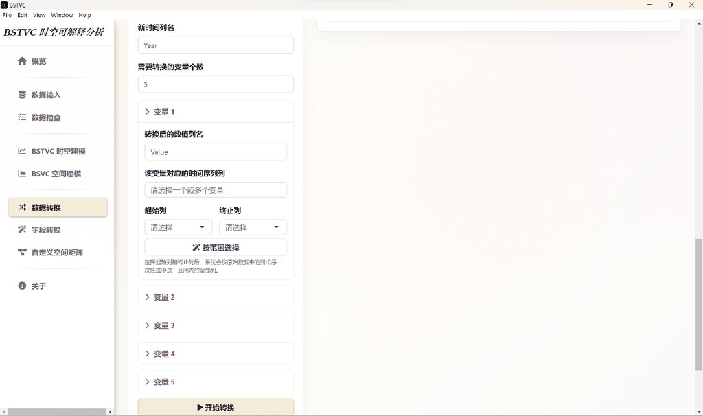

Step 5

以COUNT变量为例，原始数据名为COUNT2012、COUNT2013…至COUNT2023，为连续的列变量，则设置转换后名统一为COUNT，起始列选择COUNT2012，终止列选择COUNT2023。选择时可以通过选择列表输入，也支持检索输入

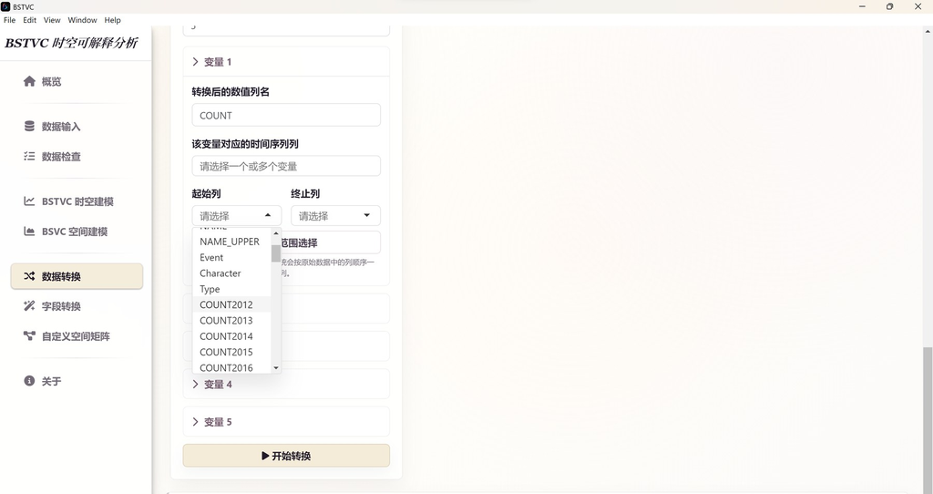

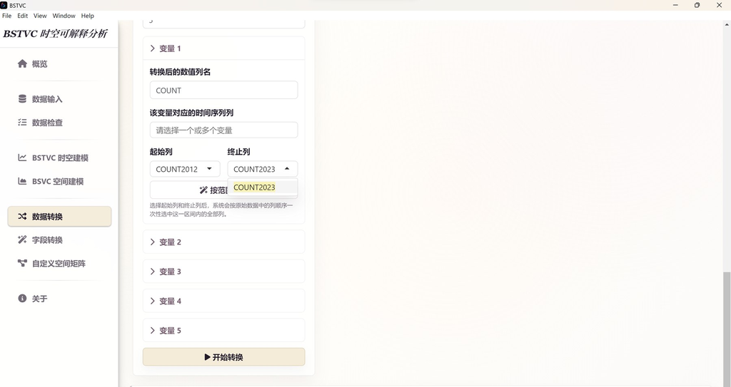

Step 6

点击按范围选择，程序会自动读取COUNT2012到COUNT2023的区间内的所有列（包含起始列和终止列），累计读取列顺序12列。按照此操作，依次读取PD、UNINS、POV、PRECIP变量，最后点击开始转换

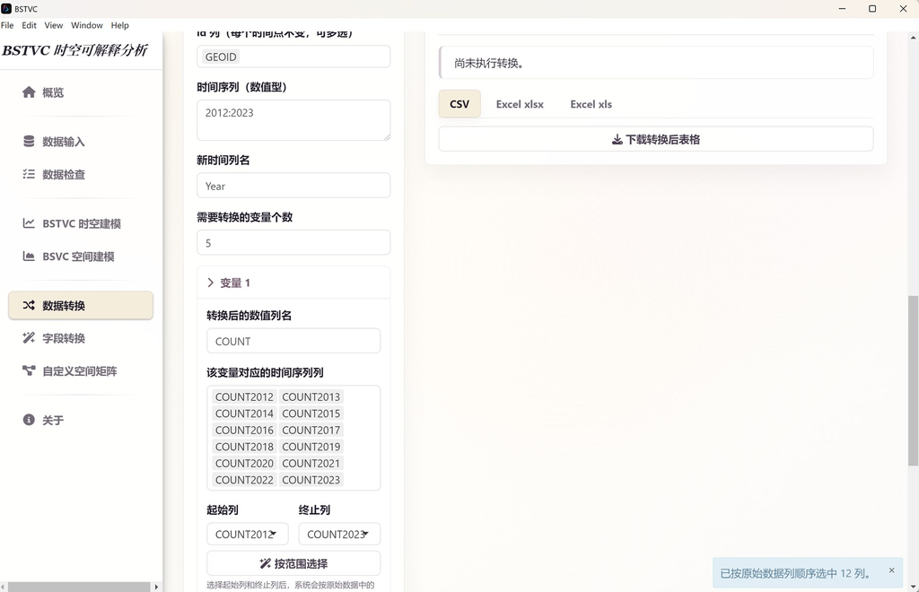

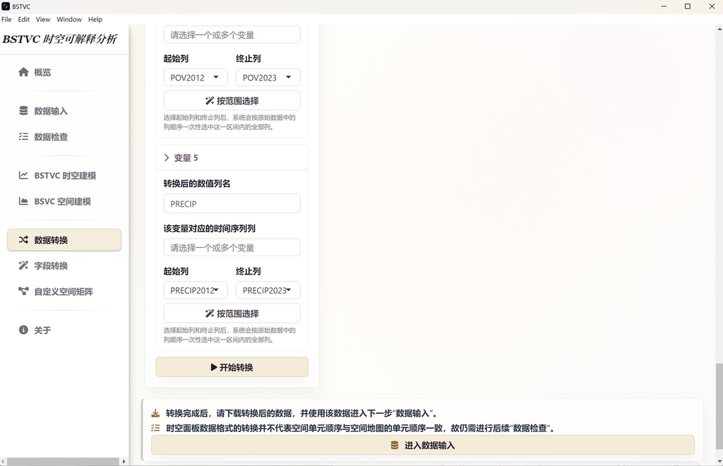

Step 7

转换完成后如下图所示。注意需下载转换后表格并存储在本地后，再进行下一步的数据输入。本程序支持.csv、.xlsx、.xls三种存储格式，本案例以存储为.xlsx格式为例进行展示

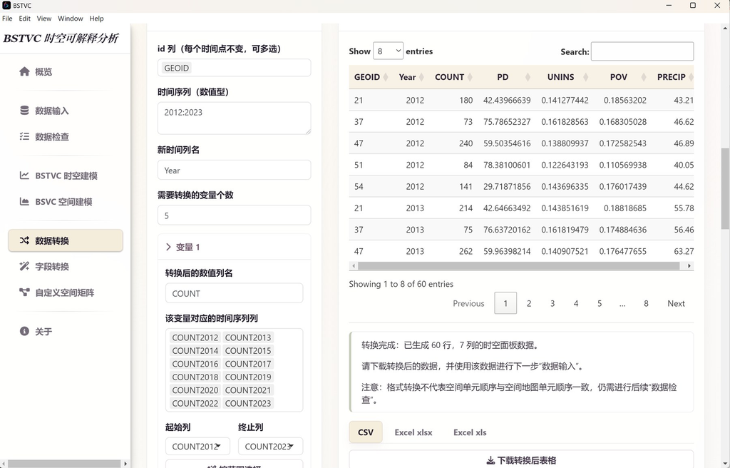

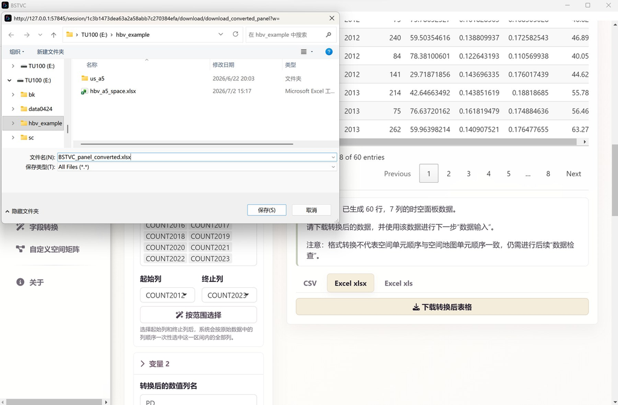

Step 8

**数据输入：**在左侧导航栏选择数据输入模块（或从上一步最底部点击进入数据输入），导入上一步存储的转换后数据，选择BSTVC_panel_converted.xlsx

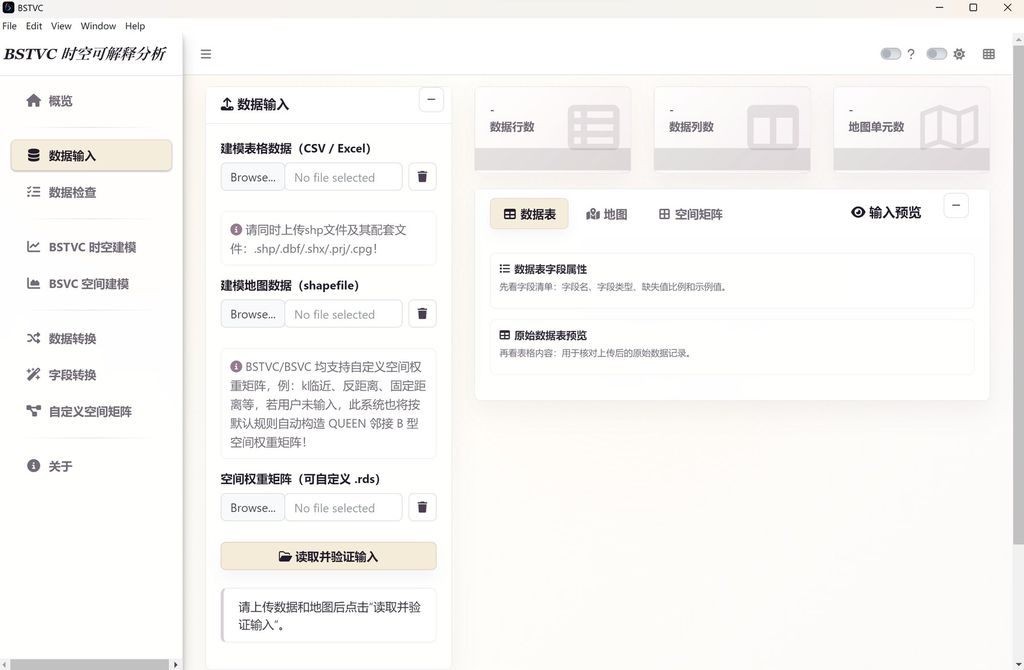

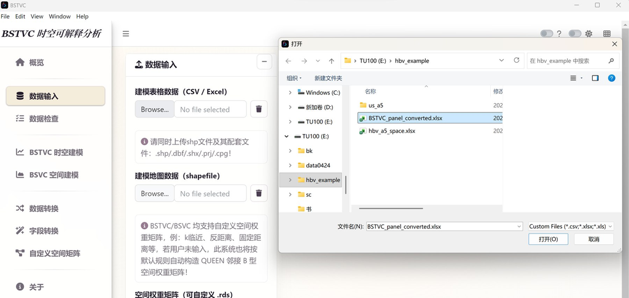

Step 9

导入建模地图数据us_a5完整文件，空间权重矩阵保持默认，不用输入设置，按默认规则自动构造QUEEN邻接型空间权重矩阵。关于自定义空间权重矩阵，可见4.2小节。

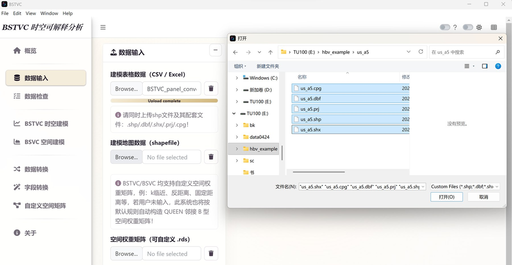

Step 10

点击读取并验证输入，导入成功后可见最左下框提示读取成功。读取成功后，右侧数据表模块上方可见数据表字段属性如字段名、字段类型、缺失值比例等；下方可见原始数据预览。

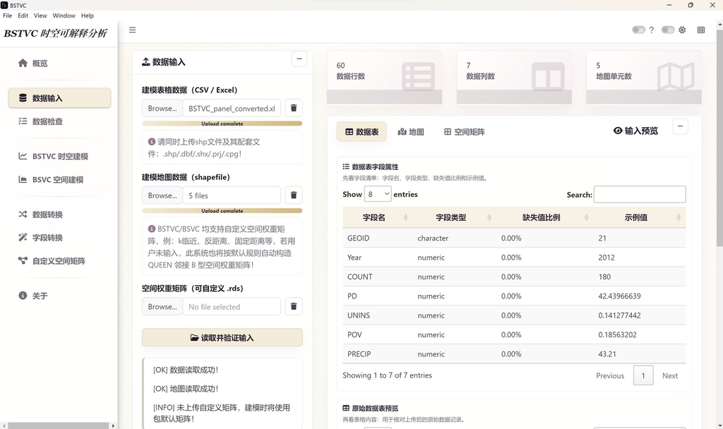

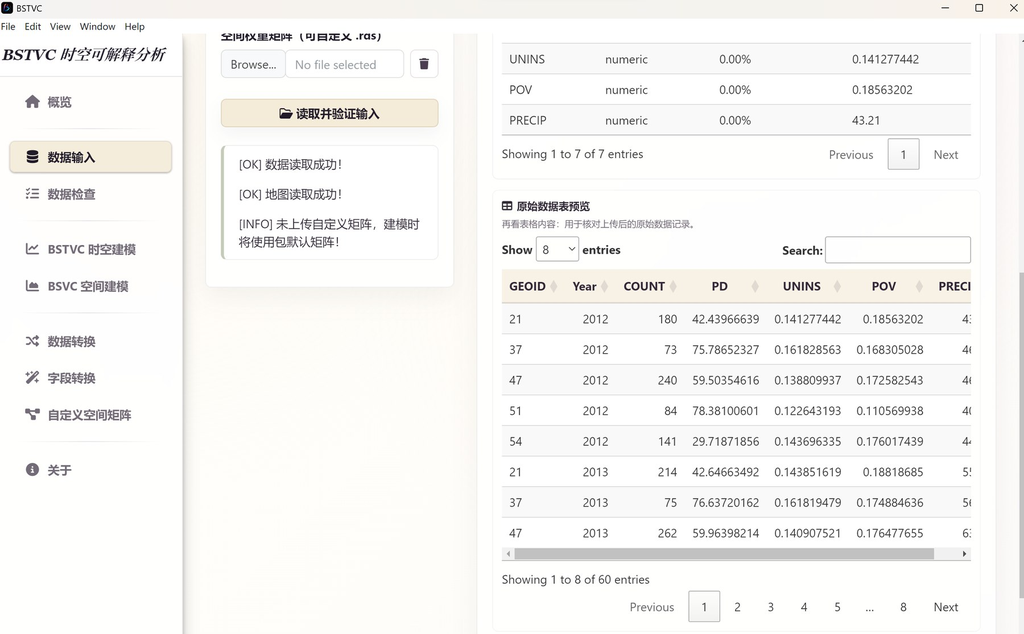

Step 11

读取成功后，右侧地图模块，上方可见地图属性模块，下方可见研究区域空间预览

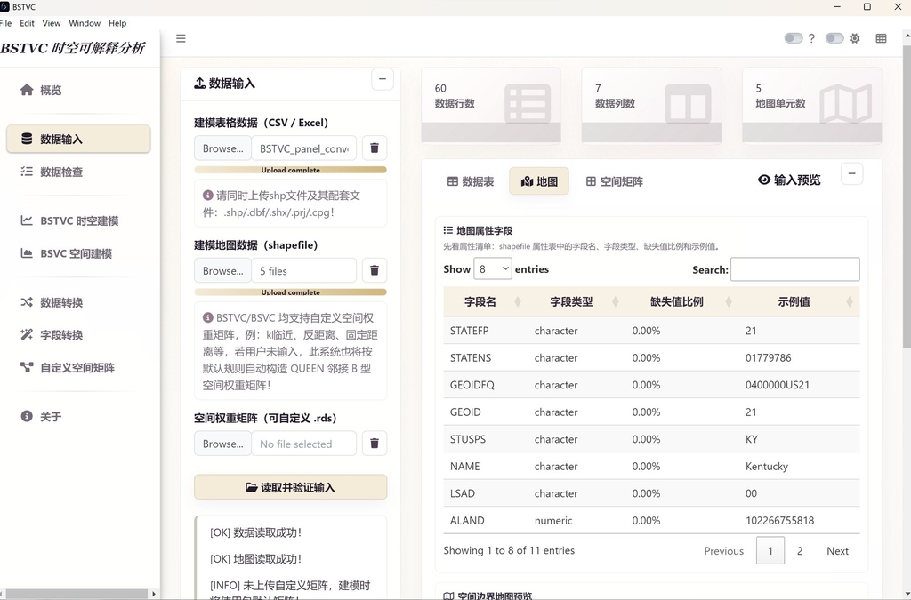

[figure not shown]

【备注】在BSTVC支持的时空面板数据中，变量Y可以包含缺失值，变量X也可容忍少量缺失值。在用户导入自己的数据前，需注意：①缺失值请使用“NA”表示，便于识别；②检查表格数据与地图数据中的空间唯一标识码的字段类型，确保两个表中的该字段的名称和类型一致。

## 6.3 数据检查

### 6.3.1 空间单元顺序检查

建模表格数据中的每个时间截面下空间单元的顺序需要与建模地图数据中的shapefile文件中空间单元的顺序完全一致，不一致会造成最终结果不正确，但模型运行并不会报错的情况。例如，地图us_a5中代表国家与地区单元的GEOID字段的顺序为21,37,47则BSTVC_panel_converted.xlsx数据中的GEOID字段也必须为此排序。

BSTVC时空可解释平台提供一键式自动比对数据表与地图中的空间单元唯一值字段的功能，完成空间序列的自动化重排与对齐

步骤说明：

Step 1

点击左侧导航栏的数据检查模块（或从上一步最底部点击进入数据检查），转入数据检查模块

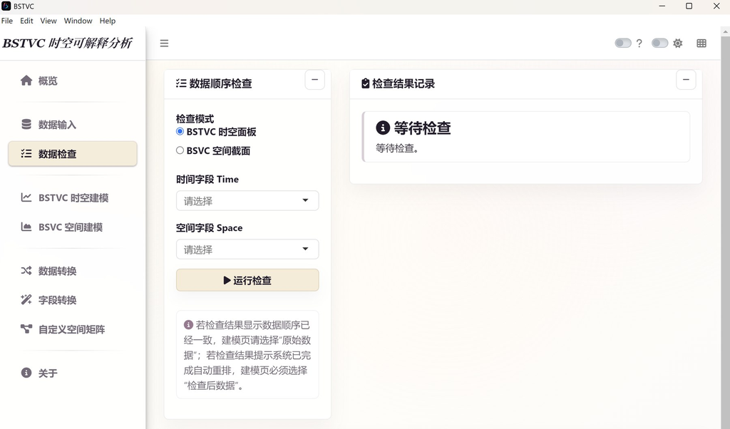

Step 2

检查模式选择BSTVC时空面板，时间字段Time选择唯一识别字段Year，空间字段Space选择唯一识别字段Geoid

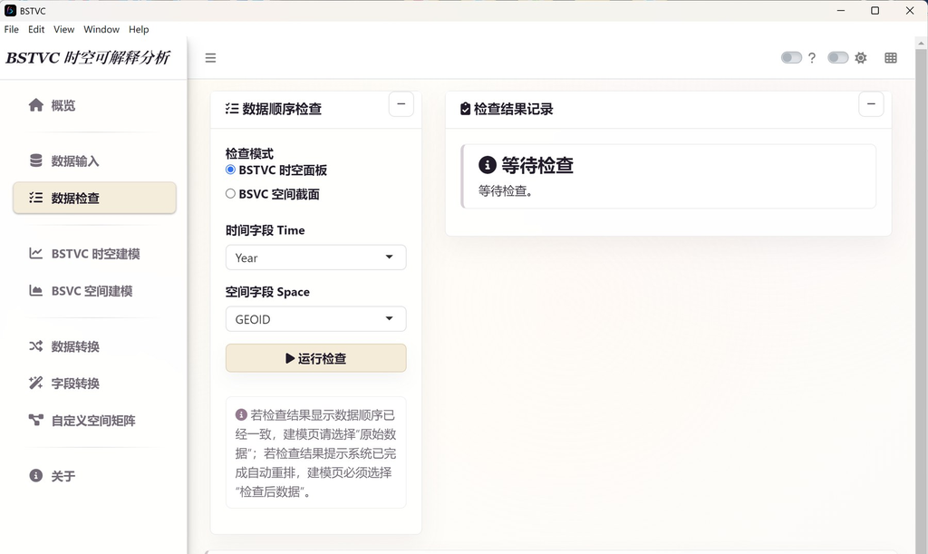

Step 3

点击运行检查，平台自动完成空间序列的重排与对齐。检查结果显示已完成后，即可选择进入BSTVC建模

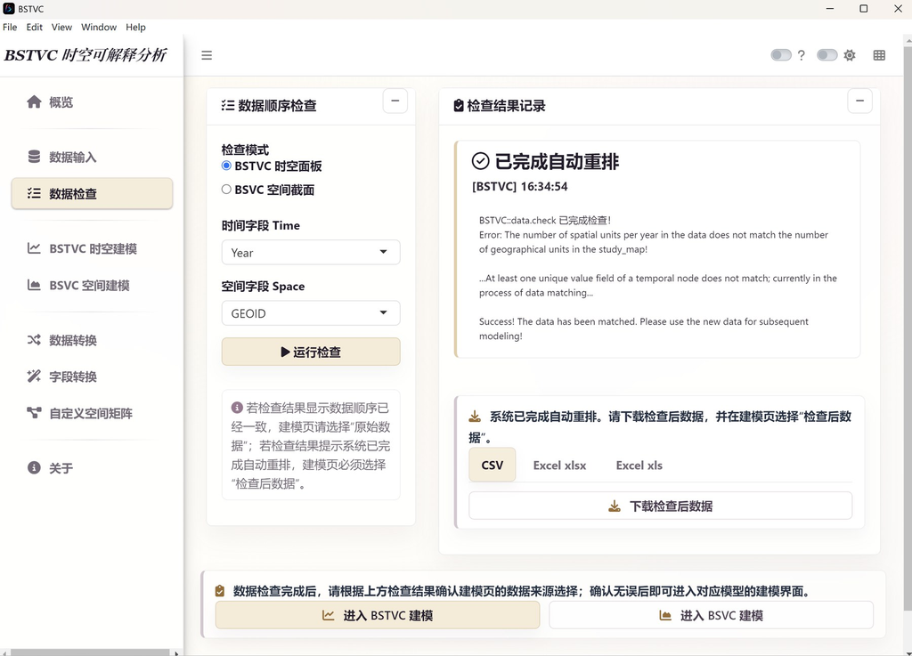

### 6.3.2 字段类型检查

在建模前，用户需要特别注意字段类型问题。具体原因、步骤及说明详见4.3.2小节。

## 6.4 BSTVC建模

构建BSTVC时空模型所需的参数主要有9个，具体参数描述详见4.4小节BSTVC时空建模。

Step 1

点击左侧导航栏的BSTVC时空建模模块（或从上一步最底部点击进入BSTVC时空建模），转入BSTVC时空建模模块

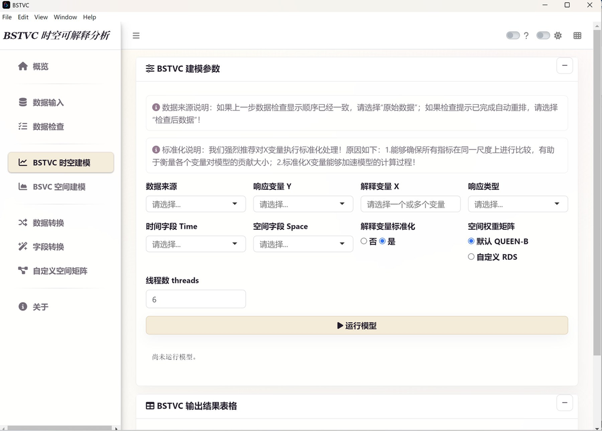

Step 2

因数据自动重排，故数据来源需选择检查后数据；优先选择解释变量标准化，空间权重矩阵默认选择QUEEN-B，线程数threads默认值为6

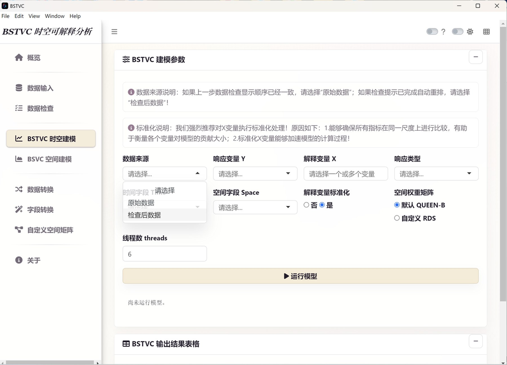

Step 3

依次输入数据的响应变量Y（本例为COUNT），解释变量X（本例为PD、UNINS、POV、PRECIP），响应类型为计数型count，时间字段为YEAR，空间字段为GEOID（务必和地图数据为同一字段名）。输入变量完成后应如下图所示

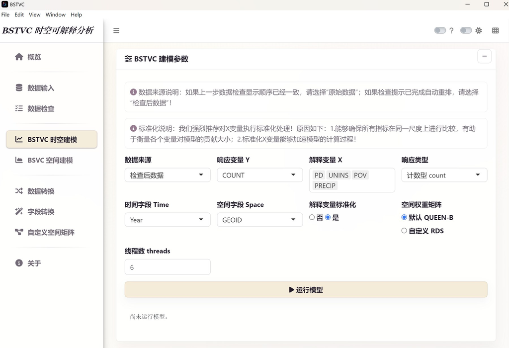

Step 4

完成上述参数准备后，点击运行模型，等待运行

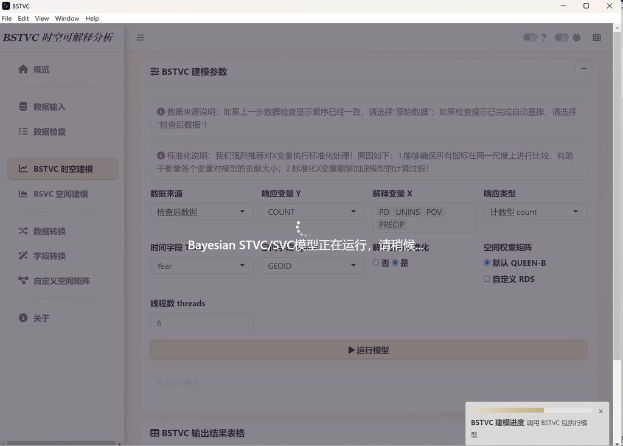

Step 5

下图是成功运行完成后的示例图。在BSTCV输出表格总计6个板块，可直接点击下载全部表格保存所有结果。本案例保存后命名为hbv_all_result.xlsx

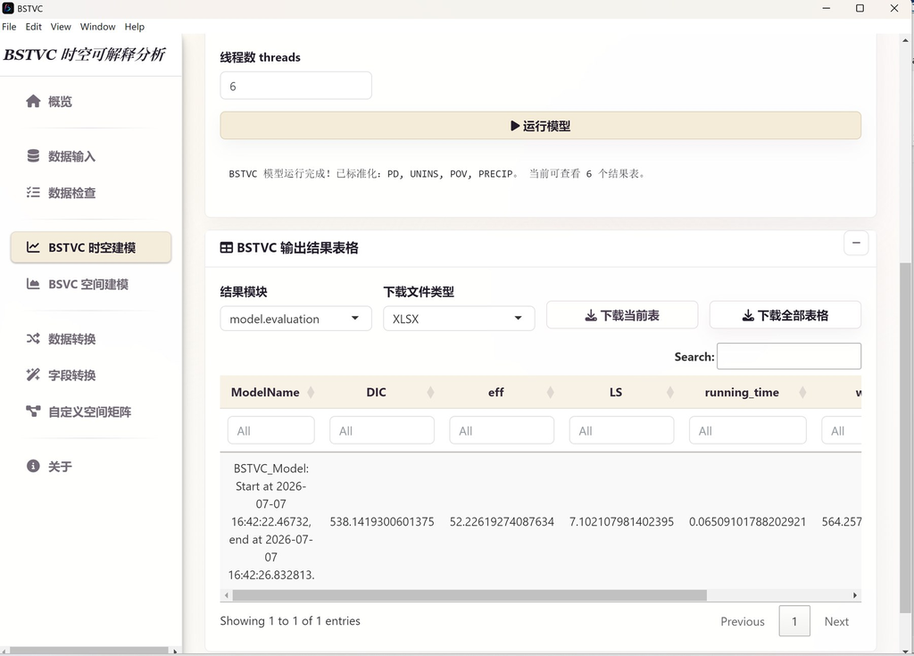

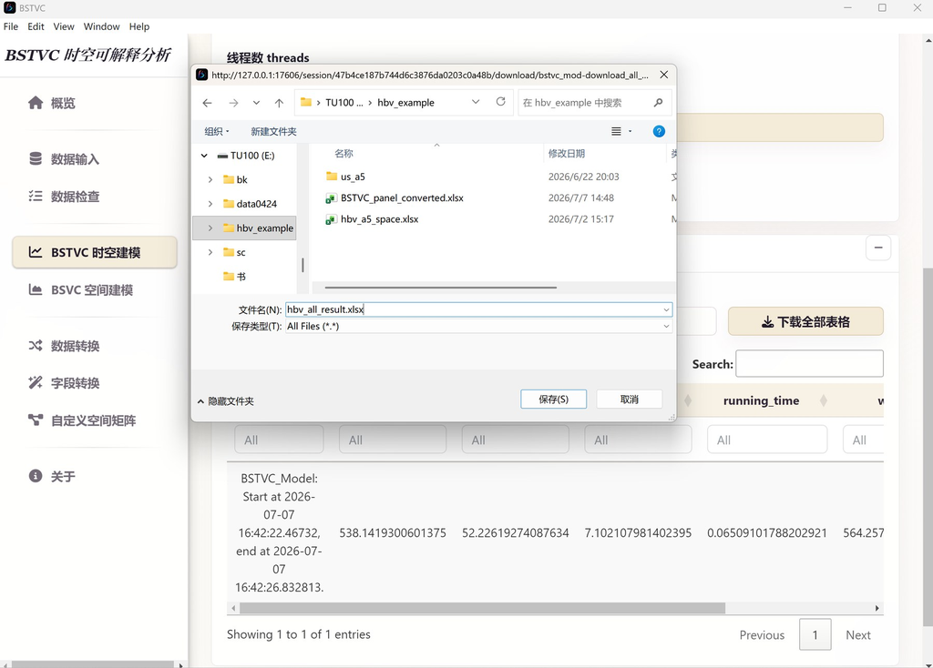

## 6.5 模型结果

BSTVC函数输出的结果共包括6个部分，具体输出部分描述同4.5小节。

## 6.6 BSTVC模型输出及其可视化

在本文档中，我们将详细提供一系列的绘制模型输出结果的步骤和代码示例，以便您能够轻松地在R环境中创建各种图表。我们的目标是让您不仅能够理解模型的输出，还能够通过图表的形式，将这些复杂的数据以更直观、更吸引人的方式呈现出来。

本文档在此部分展示的所有图表和可视化结果均基于示例数据构建的模型的输出。以下绘图代码及图件供参考

### 6.6.1 基础R包配置与数据读入

```
#BSTVC 函数的输出及其可视化
# 0 R包配置 ----------------------------------------------------------
library(readxl) # 读取 Excel 文件，如 .xls 和 .xlsx
library(sf) # 处理空间矢量数据，如 shp 文件、坐标系和空间分析
library(stringr) # 字符串处理，如提取、替换、匹配文本
library(ggplot2) # 绘图核心包，用于构建各类统计图形
library(dplyr) # 数据整理，如筛选、分组、汇总和变量变换
library(tidyr) # 数据整形，如宽表转长表、长表转宽表
library(ggthemes) # 提供额外的 ggplot2 主题，如 theme_few()
library(forestplot) # 绘制森林图，常用于展示回归系数和置信区间
library(ggbeeswarm) # 绘制蜂群图，展示分组散点且减少点重叠
library(scales) # 坐标轴、图例和数值格式化，如百分比、颜色渐变
# 1 数据读入 -----------------------------------------------------------
setwd("C:/Users/XXXX ") #实际存储工作目录
# 读取.xlsx文件中的各类sheet表结果，并存为对应数据框
model.eval <- read_excel("hbv_all_result.xlsx", sheet = "model.evaluation")
predict <- read_excel("hbv_all_result.xlsx", sheet = "local.prediction")
time.coefficients <- read_excel("hbv_all_result.xlsx", sheet = "time.coefficients")
space.coefficients<- read_excel("hbv_all_result.xlsx", sheet = "space.coefficients")
stvpi<- read_excel("hbv_all_result.xlsx", sheet = "STVPI")
#读取地图数据
us_a5<- st_read("C:/Users/XXX/us_a5")
```

### 6.6.2 模型的贝叶斯评价

模型的贝叶斯评价包括模型名称（包含建模起始时间）、DIC、LS、WAIC、pd2等指标。其中，DIC、WAIC表示模型拟合度，eff（DIC）和pd2（WAIC）表示模型复杂度，LS表示预测精度。具体而言，DIC和WAIC值越小表示模型拟合度越好，eff和pd2值越小表示模型复杂度越低，LS值越接近0表示预测精度越高。

```
# 2 模型的贝叶斯评价 ---------------------------------------------------------------
##指标水平展示
print(model.eval)
##指标垂直展示，因首列含中文故需使用t()转置
model.eval_t <- t(model.eval)
print(model.eval_t)
```

- 结果如下：

[figure not shown]

### 6.6.3 时间回归系数（时间非平稳）

BSTVC模型不仅可以计算时间回归系数来刻画变量关系的时间异质性，还可以估算出每个回归系数值的贝叶斯宽（95%）、窄（50%）可信区间，用于直接评价结果的不确定性。

1）初始数据处理

```
# 3 时间非平稳 -----------------------------------------------------------------
# 提取模型输出中的时间回归系数，添加系数字段与可信区间字段
Time.Coef <- time.coefficients %>%
mutate(
Coefficients = round(mean, 2),
`95%CI` = paste0("(", round(`0.025quant`, 2), " - ", round(`0.975quant`, 2), ")")
)
# 将时间字段转换为年份（可做可不做）
Time.Coef <- Time.Coef %>% mutate(Year = case_when(
time_index == 1 ~ 2012,
time_index == 2 ~ 2013,
time_index == 3 ~ 2014,
time_index == 4 ~ 2015,
time_index == 5~ 2016,
time_index == 6~ 2017,
time_index == 7~ 2018,
time_index == 8~ 2019,
time_index == 9~ 2020,
time_index == 10~ 2021,
time_index == 11~ 2022,
time_index == 12~ 2023,
))
```

2）第一种制图-时间系数不确定性带图

```
## 时间回归系数的时间序列展示形式（第一种制图-时间系数不确定性带图）
p3_1 <- ggplot(data=Time.Coef,aes(x=Year,y= Coefficients ,fill=explain_variable))+
geom_ribbon(aes(ymin=`0.025quant`,ymax=`0.975quant`,fill=explain_variable),alpha=0.1)+
geom_ribbon(aes(ymin=`0.25quant`,ymax=`0.75quant`,fill=explain_variable),alpha=0.5)+
geom_line(aes(x=Year,y= Coefficients,colour=explain_variable),alpha=0.8)+
facet_wrap(~explain_variable,scale = "free_y",axes = "all_x")+
theme_few()+
labs(
title = NULL,
x = "年份",
y = "时间系数 (TCs)",
fill = "解释因子",
colour = "解释因子"
)

p3_1

#保存图片结果
ggsave(
"time_coefficients_1.png",
p3_1,
width = 12,
height = 8,
dpi = 300
)
```

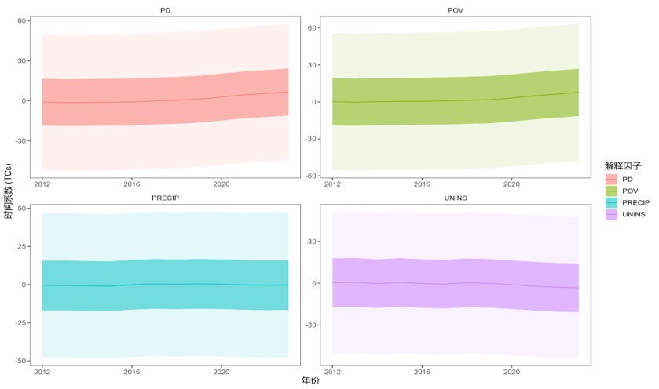

3）第二种制图-多变量折线图

为避免对时间变化形式作出线性假设，本例采用LOESS局部加权回归对年度时间系数进行平滑展示，并保留原始估计点以反映真实年度波动。

```
## 时间回归系数（第二类制图：原始点 + LOESS 平滑曲线 + 95%置信区间）
p3_2 <- ggplot(
Time.Coef,
aes(x = Year, y = Coefficients, colour = explain_variable, fill = explain_variable)

) +

geom_point(
shape = 21,
size = 2.2,
alpha = 0.75,
color = "white",
stroke = 0.4

) +

geom_smooth(
se = TRUE,
method = "loess",
linewidth = 1.2,
span = 0.8,
alpha = 0.18

) +

scale_x_continuous(
breaks = sort(unique(Time.Coef$Year))

) +

theme_few() +
labs(
title = NULL,
x = "年份",
y = "时间系数 (TCs)",
fill = "解释因子",
colour = "解释因子"

) +

theme(
legend.title = element_text(face = "bold"),
axis.title = element_text(face = "bold")
)

p3_2

#保存图片结果
ggsave(
"time_coefficients_2.png",
p3_2,
width = 12,
height = 8,
dpi = 300
)
```

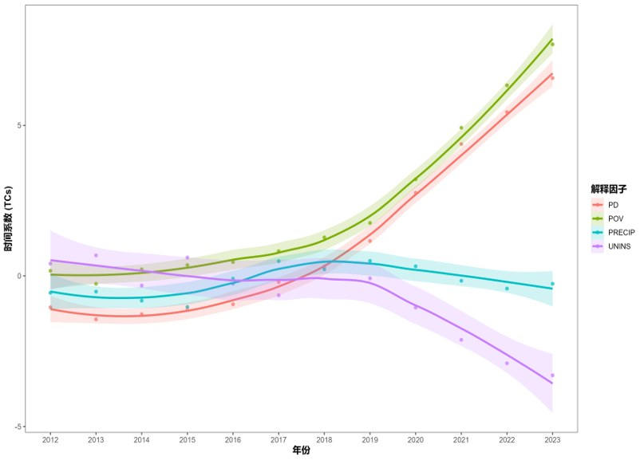

### 6.6.4 空间回归系数（空间非平稳）

与时间回归系数类似，BSTVC模型不仅可以计算空间回归系数表示空间异质的变量关系，还可以 估算其不确定性，即贝叶斯宽（95%）、窄（50%）可信区间。

提取出模型输出中的空间回归系数数据框后，建议在ArcGIS或ArcGIS Pro等专业地图制图软件中进行绘制。此处基于R语言，简单绘制出基础的空间回归系数地图展示结果，仅供样本制图参考。

```
# 4 空间非平稳 -----------------------------------------------------------------
# 统一 GEOID 格式
us_a5 <- us_a5 %>%
mutate(GEOID = str_pad(as.character(GEOID), width = 2, pad = "0"))
space.coefficients <- space.coefficients %>%
mutate(GEOID = str_pad(as.character(GEOID), width = 2, pad = "0"))
# 合并地图和空间系数
Space.Coef.merge <- left_join(us_a5, space.coefficients, by = "GEOID")
# 需要绘图的空间系数字段,务必确保一一对应!
coef_vars <- paste0(

c(

"PD",
"POV",
"UNINS",

"PRECIP"
),
"_mean"

)
# 转成长表
Space.coef.panel <- Space.Coef.merge %>%
pivot_longer(
cols = all_of(coef_vars),
names_to = "variable",
values_to = "SCs"
) %>%
mutate(
variable = gsub("_mean$", "", variable),
SCs = as.numeric(SCs)
)
# 检查 variable 是否存在

names(Space.coef.panel)

# 绘图
p4 <- ggplot(Space.coef.panel) +
geom_sf(aes(fill = SCs)) +
facet_wrap(~ variable, shrink = FALSE, drop = FALSE) +
scale_fill_gradient(
low = "#d9f1e6",
high = "#4e5180",
name = "空间系数 (SCs)"

) +

theme_few()

p4

#保存图片结果
ggsave(
"space_coefficients.png",
p4,
width = 12,
height = 8,
dpi = 300
)
```

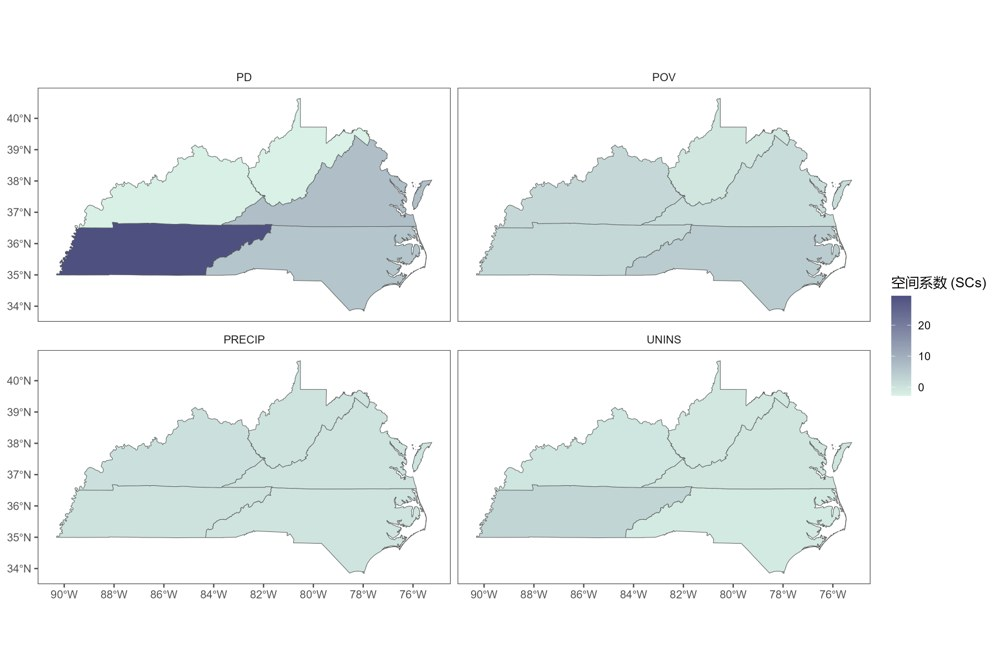

### 6.6.5 时空贡献度评价

**时空方差分割指标（Spatiotemporal Variance Partitioning Index，STVPI）**旨在量化并比较不同时空异质影响因素的可解释百分比，通过计算时空贡献度来明确关键驱动因素。基于BSTVC建模结果，STVPI进一步将每个解释变量的总方差分解为时间和空间两个独立的组分，即时间非平稳随机效应和空间非平稳随机效应，进而揭示数据的时空变异来源。

**此工具的优点有：**①不仅能识别解释因子的时空总体贡献，还能分别识别时间和空间维度的贡献；②相比只能识别绝对贡献排序的主流方法（如随机森林、SHAP等），STVPI识别的是相对贡献 （可解释百分比），为地理时空归为提供重要证据基础；③直接评价其不确定性（贝叶斯宽窄可信区间）

```
# 5 STVPI时空方差分割指标 -------------------------------------------------------------
random.effects <- c(
"space.all",
"time.all",
"space.PD",
"space.POV",
"space.PRECIP",
"space.UNINS",
"time.PD",
"time.POV",
"time.PRECIP",
"time.UNINS",
"space.time.PD",
"space.time.POV",
"space.time.PRECIP",

"space.time.UNINS"

)
plot.data <- as.data.frame(
stvpi[stvpi$`random effects` %in% random.effects, ]
) %>%
mutate(
Group = case_when(
`random effects` %in% c("space.all", "time.all") ~ "Space & Time",
grepl("^space\\.time\\.", `random effects`) ~ "space - time",
grepl("^space\\.", `random effects`) ~ "space",
grepl("^time\\.", `random effects`) ~ "time",
TRUE ~ NA_character_
)
) %>%
filter(!is.na(Group)) %>%
mutate(
Group = factor(
Group,
levels = c("space", "time", "space - time", "Space & Time")

),

label = scales::percent(STVPI_mean, accuracy = 0.01)
)
plot.data <- plot.data %>%
group_by(Group) %>%
mutate(
y_order = factor(
`random effects`,
levels = rev(`random effects`)
)
) %>%

ungroup()

p5 <- ggplot(plot.data, aes(x = STVPI_mean, y = y_order)) +
geom_errorbarh(
aes(
xmin = `STVPI_2.5%`,
xmax = `STVPI_97.5%`,
colour = `random effects`

),

height = 0,
linewidth = 1.8,
alpha = 0.3

) +

geom_errorbarh(
aes(
xmin = `STVPI_25%`,
xmax = `STVPI_75%`,
colour = `random effects`

),

height = 0,
linewidth = 1.8,
alpha = 0.6

) +

geom_point(
aes(colour = `random effects`),
shape = 21,
fill = "white",
size = 1.8,
alpha = 1

) +

geom_text(
aes(label = label),
hjust = -0.15,
size = 3,
show.legend = FALSE

) +

facet_wrap(
~ Group,
scales = "free",
ncol = 3

) +

scale_x_continuous(
labels = scales::percent_format(accuracy = 1),
expand = expansion(mult = c(0.05, 0.25))

) +

labs(
title = "",
x = "STVPI",
y = ""

) +

theme_few() +
theme(
legend.position = "none",
strip.text = element_text(size = 12),
axis.text.y = element_text(size = 10)
)

p5

#保存图片结果
ggsave(
"STVPI.png",
p5,
width = 12,
height = 8,
dpi = 300
)
```

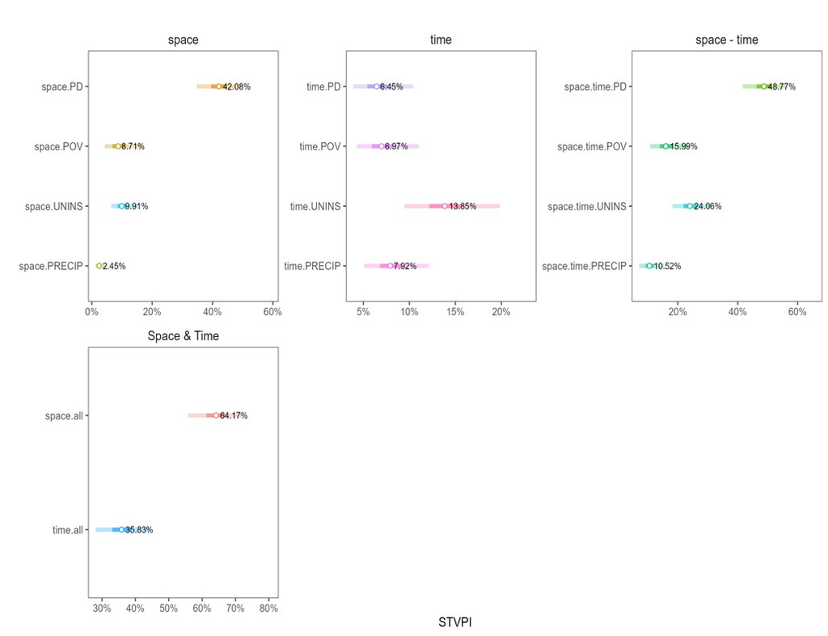